# Supplementary Analysis Appendix

Parallel elevation filtering of Ericaceae root-associated fungal communities in Andean páramo ecosystems

## Overview and reproducibility

This document compiles methodological details, supplementary analyses, and reproducibility outputs supporting the main manuscript. Computationally intensive steps (e.g. phylogenetic tree inference, genus-level GLMM fitting, iNEXT3D diversity estimation) were executed on a remote Ubuntu-based computing environment. Their outputs (figures, tables, and selected model objects) are integrated here as static results.

All figures (PNG) and result tables (CSV) are stored within the project repository using relative paths. Rendering this document therefore requires cloning the repository and opening the .qmd file from the repository root.

**Data availability.**

Repository: Paramo_SkyIslands_RootFungi  
Sequence data: ENA accession number PRJEB107725  
Metadata: `Data_S1_metadata.csv, Data_S3_soil.csv`

If viewing the PDF version of this Appendix material, note that the HTML version has all code to reproduce these results accessible through drop-downs.

Please visit the project webpage for this: https://ssangulo.github.io/Paramo_SkyIslands_RootFungi/appendix.html

## Section 0: Setup

Output directory paths and shared aesthetic constants used throughout this document. All packages are loaded locally within each code section.

```r
# Output folders used by table/figure chunks
out_fig_dir <- "figures"
out_tab_dir <- "tables"
out_obj_dir <- "objects"

# Shared colorblind-safe palette (Wong 2011) — used in all main figures
site_colors <- c(BEL = "#E69F00", DOM = "#009E73", MA = "#56B4E9", NV = "#D55E00")
site_labels <- c(BEL = "Belmira", DOM = "Las Domínguez", MA = "Matarredonda", NV = "La Nevera")

# Habitat colors (Figure 3A; kept distinct from site_colors above)
habitat_colors <- c("Forest" = "#332288", "Subpáramo" = "#AA4499", "Páramo" = "#661100")

# Shared base theme — all main figures use theme_classic(base_size = 11)
# (Defined per-chunk as base_theme; replicated here for reference)
# base_theme <- theme_classic(base_size = 11) + theme(...)

# Habitat label mapping (lowercase raw → display)
labs_map  <- c(forest = "Forest", subparamo = "Subpáramo", paramo = "Páramo")
lvl_order <- c("Forest", "Subpáramo", "Páramo")
```

## Section 1: Data and object loading

All pre-computed R objects are loaded here. Computationally intensive analyses (genus-level GLMMs, iNEXT3D, NTI/NRI, phylogeny inference) were executed on a remote server; their outputs are stored in `objects/` and loaded as needed.

**How this document relates to the code.** All analysis chunks in this appendix are set to `eval: false`: rendering the document does not re-run any analysis. Tables are read from the saved CSV files in `tables/` and figures are embedded from `figures/`. The analyses of the revision (Sections 4.3, 5.2–5.3, 6, 8 and 10) are run by the scripts in `Scripts/`, in the order given by `Scripts/run_revision.sh`, from the repository root; each code chunk below names the script that produces the corresponding outputs.

**Software versions.** Revision analyses were run in R 4.5.2 with vegan 2.7.2, phyloseq 1.54.0, iNEXT.3D 1.0.12 and glmmTMB 1.1.14, and reproduced independently in R 4.3.3 (vegan 2.7.2, phyloseq 1.46.0, iNEXT.3D 1.0.12, glmmTMB 1.1.9, betareg 3.2.4, emmeans 2.0.4, picante 1.8.2), with all tables identical to within 10⁻⁶. The vegan version matters for the composition analyses: from vegan 2.7-1, `decostand(method = "rclr")` and `vegdist(method = "robust.aitchison")` impute zeros by default, which does not reproduce the published robust CLR (zeros kept at zero). The code in Section 4 therefore computes the transform explicitly (`rclr_std()`).

```r
# Main analysis phyloseq object (root-only; replicates collapsed; soil reads removed; decontam applied)
ps_individual <- readRDS(file.path(out_obj_dir, "ps_individual.rds"))

# Phyloseq object with phylogenetic tree (two root replicates kept separate)
tree_ps <- readRDS(file.path(out_obj_dir, "tree_ps.rds"))

# Genus-level GLMM heatmap plot object (generated by Scripts/Figure4_pooled_glmm.R)
p_heat <- readRDS(file.path(out_obj_dir, "p_heat_glmm.rds"))
```

## Section 2: Bioinformatics summary and study design

### 2.1 Study sites and sampling

This study was conducted across four humid páramo regions in the Colombian Andes, spanning the Central and Eastern Cordilleras. Sampling locations covered elevations from 2,715 to 3,828 m a.s.l., representing the ecological transition from Andean forest to páramo (see main text, Fig. 1). The full sample metadata table is provided in Data_S1_metadata.csv.

Root sampling followed standardized sterile procedures. Fine roots of Gaultheria myrsinoides were excavated using a spade, and 3–5 cm root tips were clipped using a sterilized pruner. Tools were disinfected with 75% ethanol between samples, and gloves were changed between individual plants to minimize contamination. Root fragments were placed into sealed polybags stored in ice-cooled containers in the field. Samples were processed at Universidad ICESI, where roots were rinsed in sterile water to remove debris, dried briefly under a laminar flow hood, and stored at –20°C prior to shipment to Norway, and long-term storage at –80°C. Soil samples (top 15 cm) were collected at each sampling location, and five aliquots of rinse water were retained as laboratory and transport controls.

**Table S1**: GPS coordinates, elevation, and vegetation type classification of the 12 sampling locations across four páramo regions. These sites span the forest–subpáramo–páramo gradient and were used for root and soil sampling. In each location, 10 root samples were collected from 5 individuals (2 root samples per individual) and 1 soil sample.

| **Site ID** | **Site** | **Altitude (m)** | **Latitude (N)** | **Longitude (W)** | **Ecosystem** |
| --- | --- | --- | --- | --- | --- |
| NV_1 | Páramo La Nevera | 3828 | 03º30’58.1” | 076º03’05.4” | Páramo |
| NV_2 | Páramo La Nevera | 3550 | 03º31’37.7” | 076º03’38.7” | Subpáramo |
| NV_3 | Páramo La Nevera | 3333 | 03º32’07.0” | 076º04’18.3” | Andean forest |
| NV_4 | Páramo La Nevera | 3078 | 03º32’48.9” | 076º04’31.3” | Andean forest |
| DOM_1 | Páramo Las Domínguez | 3815 | 03º43’51.8” | 076º06’38.1” | Páramo |
| DOM_2 | Páramo Las Domínguez | 3534 | 03º44’07.2” | 076º05’53.2” | Subpáramo |
| DOM_3 | Páramo Las Domínguez | 3234 | 03º44’17.1” | 076º05’32.9” | Andean forest |
| BEL_1 | Páramo Belmira | 3254 | 06º38’43.8” | 075º40’13.3” | Subpáramo |
| BEL_2 | Páramo Belmira | 2950 | 06º38’22.7” | 075º39’57.3” | Andean forest |
| BEL_3 | Páramo Belmira | 2715 | 06°36’55.3” | 075°39’51.1” | Andean forest |
| MA_1 | Páramo Matarredonda | 3678 | 04º33’31.5” | 074º01’43.8” | Páramo |
| MA_2 | Páramo Matarredonda | 3381 | 04º33’10.3” | 073º59’35.3” | Subpáramo |

### 2.2 Read filtering, OTU table, and taxonomic assignment

This section provides supplementary details on sequencing read processing and quality filtering. The full bioinformatic pipeline (including DADA2 processing and replicate filtering) is available in the repository at “/Scripts/full_pipeline_DADA2.R”. Here we report summary tables of read retention and replicate-filtering thresholds used for downstream analyses.

**Table S2**: Median read numbers per PCR replicate for environmental samples (root and soil samples) and controls (blank extractions, positive, PCR blank, and tag-jump controls). The read counts are grouped at each stage of the DADA2 pipeline. Blank extraction controls (not containing any biological sample) were performed alongside real sample DNA extractions per each extraction batch. PCR blank controls contained all PCR reagents but no DNA template. Tag-jump controls are PCR reactions containing no primers and no DNA template, used to detect tag-jumping (index hopping).

|  | **Raw reads** | **Filtered** | **Merged - Non pooled** | **Merged - Pooled** | **Merged - Pseudopooled** |
| --- | --- | --- | --- | --- | --- |
| **Root samples** | 77,047 | 71,783 | 71,084 | 70,343 | 71,242 |
| **Soil samples** | 72,158 | 66,555 | 65,311 | 65,498 | 65,385 |
| **Blank Extraction Controls** | 2,844 | 2,652 | 2,618 | 2,566 | 2,625 |
| **Positive Controls** | 95,238 | 88,174 | 88,062 | 87,996 | 87,972 |
| **PCR Blank Controls** | 291 | 261 | 250 | 257 | 256 |
| **Tag-jump Controls** | 41 | 36 | 27 | 30 | 32 |

Table S3. Number of OTUs and samples after applying different replicate control filtering thresholds. The table shows results for both soil and root samples combined and only root samples.

| Filtering_level | OTU_count_soil+root | Samples_soil+root | OTU_count_root_only | Samples_root_only |
| --- | --- | --- | --- | --- |
| No filtering | 18451 | 132 | 13225 | 120 |
| OTU present in 2/4 | 7174 | 132 | 4386 | 120 |
| OTU present in 3/4 | 4870 | 131 | 2966 | 120 |
| OTU present in 4/4 | 2875 | 113 | 1904 | 103 |

**Table S4**: Summary of the percentage of reads and OTUS with confident taxonomic assignment at each taxonomic rank, represented by habitat. Percentages were calculated from the filtered root-only dataset (soil reads removed).

| **Rank** | **Habitat** | **%_reads_assigned** | **%_otus_assigned** |
| --- | --- | --- | --- |
| Phylum | Forest | 88,1 | 88,1 |
| Phylum | Subpáramo | 91,6 | 88,6 |
| Phylum | Páramo | 92,9 | 89,3 |
| Class | Forest | 78,3 | 72,5 |
| Class | Subpáramo | 84,2 | 72,3 |
| Class | Páramo | 84,3 | 76,0 |
| Order | Forest | 68,3 | 59,2 |
| Order | Subpáramo | 74,2 | 57,1 |
| Order | Páramo | 78,2 | 60,9 |
| Genus | Forest | 32,8 | 34,2 |
| Genus | Subpáramo | 32,1 | 32,2 |
| Genus | Páramo | 31,4 | 32,7 |

### 2.3 Soil background subtraction

Soil controls were used as a third tier of negative control, alongside PCR blanks and extraction blanks, and were applied as a *count subtraction* rather than as a sample-level exclusion. Within each sampling location, the maximum read count observed per OTU across that location’s co-sampled soil control(s) was subtracted from every root PCR replicate collected at the same location, and any resulting negative value was set to zero. The subtraction was applied to raw read counts, before the two-PCR-replicate detection filter and before PCR replicates were collapsed into samples; soil rows were then removed, leaving the root-only dataset used in all downstream analyses. If a location group contained no matching soil row the per-OTU maximum is undefined, and the affected values were reset to zero. The identical operation had already been applied one step earlier using PCR blanks and extraction blanks as the reference rows.

**Soil background subtraction (from Scripts/full_pipeline_DADA2.R)**

```r
# Applied within each sampling location (the OTU table is split by Fieldcontrol
# before this function is mapped over the resulting list). Rows = PCR replicates,
# columns = OTUs. mind is the per-OTU maximum across that location's soil controls.
fb.blank.change <- function(x){
  mind <- apply(x[grep("S_S1_1|S_S1_2|S_S1_3|S_S1_4|S_S1_5|S_S1_6|S_S1_7|S_S2_1|S_S2_2|S_S2_3|S_S2_4|S_S2_5", rownames(x)), ], 2, function(y) max(y, na.rm = TRUE))
  x1 <- sweep(x, 2, mind)   # subtract the local soil background, per OTU
  x1 <- pmax(x1, 0)         # floor negative counts at zero
  return(x1)
}
```

**What this removes, and what it does not.** Because the operation subtracts a background level rather than deleting shared taxa, it does not exclude fungi that occur in both soil and roots. An OTU is lost from a given root sample only where its root read count does not exceed the soil maximum at that location; taxa genuinely enriched in roots retain their excess signal. Consistent with this, 1,269 of the 3,689 OTUs recovered from soils were also retained in the final root dataset, and *Leohumicola* — abundant in both compartments — remains one of the dominant root genera (main-text Figure 4C). Root-associated fungi with a soil interface, and dormant propagules of root-associated taxa residing in the soil pool, are therefore represented in the analysed data. The rationale is not that soil-derived taxa are uninformative, but that each root sample is corrected against soil from its own location, which removes precisely the component of root community variation that tracks local soil composition; habitat signal that survives this correction is consequently not attributable to soil carry-over from incomplete root washing or recalcitrant surface-bound cells.

**Depth dependence — an acknowledged limitation.** The subtraction operates on raw counts and is not normalised for the sequencing depth of the soil control relative to each root sample. Median depths were comparable between the two sample types (65,311 versus 71,084 reads per PCR replicate after merging under the non-pooled strategy; Table S2), so the correction is not grossly asymmetric, but it remains depth-dependent: a fixed count is removed from root samples that differ in depth, so its proportional effect is larger in shallow-sequenced samples and largest for taxa spanning the soil–root continuum. The procedure therefore trades one source of bias (incomplete root washing, surface-bound soil taxa) for another (depth-dependent magnitude of count removal), and it is conservative with respect to root–soil overlap: genuine overlap is removed together with carry-over. The communities analysed here are accordingly best interpreted as the root-enriched fraction of the fungal community rather than as the complete root mycobiome.

## Section 3: Taxonomic overview

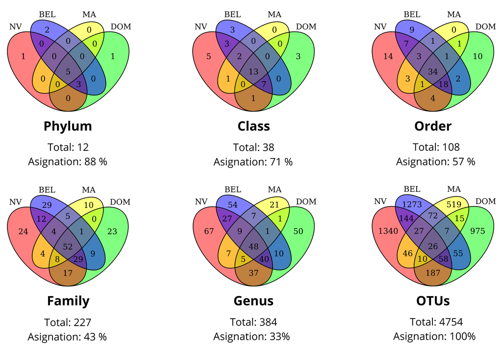

**Figure S1**: Venn diagram of taxonomic assignments across sampling sites, in the root only dataset, but previous to soil sequences removal. Venn diagrams illustrate the overlap of OTU taxonomic assignments across four study sites: La Nevera (NV), Las Domínguez (DOM), Belmira (BEL), and Matarredonda (MA). Only OTUs with confirmed assignments at each taxonomic level are included.

[figure not shown]

**Figure S2**: Taxonomic composition in root samples along the elevational gradient. Relative read abundances are shown at three taxonomic ranks: A) Phylum, B) Genus and C) Order. Each bar represents an individual root sample, grouped by habitat: Forest (2700-3300 m), Subpáramo (3300-3500 m), and Páramo (3800 m). Study sites are indicated on the y-axis.

[figure not shown]

**Figure S3**: Taxonomic composition in soil samples, collected at each of the sampling locations. Relative read abundances are shown at three taxonomic ranks: A) Phylum, B) Genus, and C) Order. Each bar represents an individual soil sample, grouped by habitat: Forest (2700-3300 m), Subpáramo (3300-3500 m), and Páramo (3800 m). Study sites are indicated on the y-axis.

**MicroViz code for taxonomic barplots (executed on server)**

```r
# MicroViz taxonomic barplots
# Code executed on remote server; plots saved as PNG and embedded above.

library(microViz)

filter_taxa_by_rank <- function(physeq_obj, rank_prefix = "o__", exclude_term = "Incertae_sedis") {
  taxa_assigned <- grepl(rank_prefix, tax_table(physeq_obj)[, "Order"])
  exclude_incertae_sedis <- !grepl(exclude_term, tax_table(physeq_obj)[, "Order"])
  taxa_filtered <- taxa_assigned & exclude_incertae_sedis
  physeq_filtered <- prune_taxa(taxa_filtered, physeq_obj)
  return(physeq_filtered)
}

ps_filtered <- filter_taxa_by_rank(alldat.N[[2]])

# Clean taxonomic prefixes like o__, g__, etc.
tax_table(ps_filtered) <- apply(
  tax_table(ps_filtered), 2, function(x) gsub("^[a-z]__", "", x)
)

# Recode habitat labels
sample_data(ps_filtered)$habitat <- dplyr::recode(
  as.character(sample_data(ps_filtered)$habitat),
  "forest"    = "Forest",
  "subparamo" = "Subpáramo",
  "paramo"    = "Páramo",
  .default = NA_character_
)


# Order the factor levels
sample_data(ps_filtered)$habitat <- factor(
  sample_data(ps_filtered)$habitat,
  levels = c("Forest","Subpáramo","Páramo"),
  ordered = TRUE
)

ps_filtered <- ps_filtered %>% ps_arrange(site)

#  within each site, order samples by Bray/OLO seriation at Order level ---
site_levels <- sample_data(ps_filtered) %>% as.data.frame() %>% pull(site) %>% unique()

samp_order <- unlist(lapply(site_levels, function(s) {
  ps_filtered %>%
    ps_filter(site == s) %>%
    ps_seriate(rank = "Order") %>%   # same tax_level you plot
    sample_names()                   # returns samples in seriated order
}))

# Barplot faceted by habitat, clean legend labels
p <- ps_filtered %>%
  comp_barplot(
    tax_level = "Order", n_taxa = 10, label = "site",
    bar_outline_colour = "grey5", facet_by = "habitat", sample_order = samp_order,
    merge_other = FALSE, other_name = "Other orders"
  ) +
  coord_flip() +
  theme(
    legend.text  = element_text(size = 6),
    legend.title = element_text(size = 7),
    legend.key.size = unit(0.3, "cm"),
    legend.spacing.x = unit(0.2, "cm"),
    plot.title = element_text(hjust = 0.5)
  )




#Plot for phylum
phy <- ps_filtered %>%
  comp_barplot(
    tax_level = "Phylum", n_taxa = 5, label = "site",
    bar_outline_colour = "grey5", facet_by = "habitat", sample_order = samp_order,
    merge_other = FALSE, other_name = "Other phyla"
  ) +
  coord_flip() +
  theme(
    legend.text  = element_text(size = 6),
    legend.title = element_text(size = 7),
    legend.key.size = unit(0.3, "cm"),
    legend.spacing.x = unit(0.2, "cm"),
    plot.title = element_text(hjust = 0.5)
  )



#Plot for class
class <- ps_filtered %>%
  comp_barplot(
    tax_level = "Class", n_taxa = 10, label = "site",
    bar_outline_colour = "grey5", facet_by = "habitat", sample_order = samp_order,
    merge_other = FALSE, other_name = "Other classes"
  ) +
  coord_flip() +
  theme(
    legend.text  = element_text(size = 6),
    legend.title = element_text(size = 7),
    legend.key.size = unit(0.3, "cm"),
    legend.spacing.x = unit(0.2, "cm"),
    plot.title = element_text(hjust = 0.5)
  )



#Plot for genus
genus <- ps_filtered %>%
  comp_barplot(
    tax_level = "Genus", n_taxa = 20, label = "site",
    bar_outline_colour = "grey5", facet_by = "habitat", sample_order = samp_order,
    merge_other = FALSE, other_name = "Other genera"
  ) +
  coord_flip() +
  theme(
    legend.text  = element_text(size = 6),
    legend.title = element_text(size = 7),
    legend.key.size = unit(0.3, "cm"),
    legend.spacing.x = unit(0.2, "cm"),
    plot.title = element_text(hjust = 0.5)
  )
```

## Section 4: Community composition

This section provides detailed statistical analyses supporting the patterns of root-associated fungal community composition described in the main text. Several of these analyses form the basis of results reported in the main manuscript; here we document the full model specifications and test statistics to ensure transparency and reproducibility.

We include distance-based redundancy analysis (dbRDA) based on robust Aitchison distances to assess habitat-associated compositional structure while conditioning on site. We further present PERMANOVA results from a balanced subset of samples (NV–DOM) used to test habitat and site effects under a controlled sampling design. In addition, we report a centroid-based turnover model quantifying the magnitude of community change across habitats using the full dataset.

### 4.1 dbRDA ordination (Tables S5–S6)

Distance-based redundancy analysis (dbRDA) was conducted on robust Aitchison distances to test for habitat-associated compositional structure while conditioning on site. This analysis is reported in the main manuscript as Figure 2A (habitat separation conditioned on site; permutation test $F=1.41$, $p=0.001$).

Table S5. dbRDA permutation tests (by term; 999 permutations).

| Component | Df | Variance | F | Pr |
| --- | --- | --- | --- | --- |
| habitat | 2 | 22.718 | 1.408 | 0.001 |
| Residual | 54 | 435.501 | NA | NA |

Table S6. dbRDA permutation tests (by constrained axis; 999 permutations).

| Axis | Df | Variance | F | Pr |
| --- | --- | --- | --- | --- |
| CAP1 | 1 | 14.579 | 1.808 | 0.001 |
| CAP2 | 1 | 8.139 | 1.009 | 0.470 |
| Residual | 54 | 435.501 | NA | NA |

**Code used to generate Tables S5–S6 and dbRDA support plot (executed on server)**

```r
#Running dbRDA with robust aitchison
library(phyloseq)
library(vegan)
library(ggplot2)
library(knitr)


ps <- ps_individual #phyloseq object

X <- as(otu_table(ps), "matrix")
if (taxa_are_rows(ps)) X <- t(X)

sam <- data.frame(sample_data(ps))
sam$habitat <- factor(sam$habitat)
sam$site    <- factor(sam$site)


# Robust CLR with zeros kept at zero (as used for the published tables).
# vegan >= 2.7-1 imputes zeros by default in decostand("rclr")/"robust.aitchison",
# which no longer reproduces Tables S5-S10, so the transform is computed explicitly.
rclr_std <- function(x) {                      # robust CLR, zeros kept at zero
  lx <- log(x); lx[!is.finite(lx)] <- NA
  out <- sweep(lx, 1, rowMeans(lx, na.rm = TRUE)); out[is.na(out)] <- 0
  out
}

# dbRDA model: habitat constrained, conditioning on site
d_ait <- dist(rclr_std(X))
mod_ait <- capscale(d_ait ~ habitat + Condition(site), data = sam)

# Permutation tests (999 permutations)
set.seed(1)
a_terms   <- anova.cca(mod_ait, by = "terms", permutations = 999)
a_axis    <- anova.cca(mod_ait, by = "axis", permutations = 999)


a_terms
a_axis

tab_terms <- data.frame(
  Term = rownames(a_terms),
  Df = a_terms$Df,
  Variance = a_terms$Variance,
  F = a_terms$F,
  Pr = a_terms$`Pr(>F)`,
  row.names = NULL
)

tab_axis <- data.frame(
  Axis = rownames(a_axis),
  Df = a_axis$Df,
  Variance = a_axis$Variance,
  F = a_axis$F,
  Pr = a_axis$`Pr(>F)`,
  row.names = NULL
)

write.csv(tab_terms, file.path(out_tab_dir, "Table_S5_dbRDA_terms.csv"), row.names = FALSE)
write.csv(tab_axis,  file.path(out_tab_dir, "Table_S6_dbRDA_axes.csv"),  row.names = FALSE)


# Plotting Figure 2A support panel
eig <- mod_ait$CCA$eig
cap1_pct <- round(100 * eig[1] / sum(eig), 1)
cap2_pct <- round(100 * eig[2] / sum(eig), 1)

cols <- c(forest="steelblue", subparamo="seagreen3", paramo="firebrick")

png("Figure2A_dbRDA_support.png", width=7.2, height=6.2, units="in", res=600)
par(mar=c(4.5,4.5,1,1))
plot(mod_ait, display="sites", type="n",
     xlab=paste0("dbRDA1 (",cap1_pct,"%)"),
     ylab=paste0("dbRDA2 (",cap2_pct,"%)"))
pts <- scores(mod_ait, display="sites")
points(pts, pch=16, cex=0.7, col=cols[as.character(sam$habitat)])
legend("topright", bty="n", legend=levels(sam$habitat),
       col=cols[levels(sam$habitat)], pch=16, pt.cex=0.9)
dev.off()
```

### 4.2 PERMANOVA and beta-dispersion (Tables S7–S9)

Beta-dispersion tests on the balanced NV–DOM subset indicated higher within-habitat variability in forests (mean distance to centroid 23.6) compared with subpáramo (17.8) and páramo (17.1) communities (F = 11.30, p = 0.001), whereas dispersion did not differ among sites (p = 0.571). Part of the PERMANOVA habitat effect may therefore reflect differences in dispersion rather than location. The significant habitat × site interaction (R² = 0.09, p = 0.001) indicates that the habitat effect on composition is not identical between the two complete gradients: a shared habitat response with a site-specific component.

Table S7. PERMANOVA (adonis2) results by term.

| Source | df | SumOfSqs | R2 | Pseudo.F | Pr..F. |
| --- | --- | --- | --- | --- | --- |
| site | 1 | 742.078 | 0.056 | 1.786 | 0.001 |
| habitat | 2 | 1351.164 | 0.102 | 1.626 | 0.001 |
| site:habitat | 2 | 1241.269 | 0.093 | 1.493 | 0.001 |
| Residual | 24 | 9974.546 | 0.749 | NA | NA |
| Total | 29 | 13309.057 | 1.000 | NA | NA |

Table S8. Habitat beta-dispersion (distance to centroid). Permutation test p = 0.001.

| habitat | avg_distance_to_centroid |
| --- | --- |
| forest | 23.631 |
| paramo | 17.147 |
| subparamo | 17.794 |

Table S9. Site beta-dispersion permutation test.

| test | permutations | F | p_value |
| --- | --- | --- | --- |
| betadisper_site | 999 | 0.314 | 0.571 |

**Code used to generate Tables S7–S9 (executed on server)**

```r
ps <- ps_individual #phyloseq obj

# Balanced subset: NV + DOM, remove NV_4
balanced_ps <- subset_samples(ps, site %in% c("DOM", "NV"))
balanced_ps <- subset_samples(balanced_ps, site_elevation != "NV_4")
balanced_ps <- prune_taxa(taxa_sums(balanced_ps) > 0, balanced_ps)

# Ensure samples are rows
X <- as(otu_table(balanced_ps), "matrix")
if (taxa_are_rows(balanced_ps)) X <- t(X)

sampledf <- data.frame(sample_data(balanced_ps))
sampledf$site    <- factor(sampledf$site)
sampledf$habitat <- factor(sampledf$habitat)

# Robust CLR with zeros kept at zero (as used for the published tables).
# vegan >= 2.7-1 imputes zeros by default in decostand("rclr")/"robust.aitchison",
# which no longer reproduces Tables S5-S10, so the transform is computed explicitly.
rclr_std <- function(x) {                      # robust CLR, zeros kept at zero
  lx <- log(x); lx[!is.finite(lx)] <- NA
  out <- sweep(lx, 1, rowMeans(lx, na.rm = TRUE)); out[is.na(out)] <- 0
  out
}

# Robust Aitchison distance
dists <- dist(rclr_std(X))

# PERMANOVA (by terms)
set.seed(1)
perma <- adonis2(dists ~ site * habitat, by = "terms", data = sampledf, permutations = 999)

# Convert output to a clean CSV table
tab_perma <- data.frame(
  Source   = rownames(perma),
  df       = perma$Df,
  SumOfSqs = perma$SumOfSqs,
  R2       = perma$R2,
  `Pseudo-F` = perma$F,
  `Pr(>F)` = perma$`Pr(>F)`,
  row.names = NULL
)

# Beta-dispersion (habitat & site)
bd_hab  <- betadisper(dists, sampledf$habitat)
bd_site <- betadisper(dists, sampledf$site)

set.seed(1)
pt_hab  <- permutest(bd_hab,  permutations = 999)
pt_site <- permutest(bd_site, permutations = 999)

# Group dispersions
disp_hab <- data.frame(
  habitat = names(bd_hab$group.distances),
  avg_distance_to_centroid = as.numeric(bd_hab$group.distances),
  row.names = NULL
)

disp_site <- data.frame(
  site = names(bd_site$group.distances),
  avg_distance_to_centroid = as.numeric(bd_site$group.distances),
  row.names = NULL
)


test_hab <- data.frame(
  test = "betadisper_habitat",
  permutations = 999,
  F = unname(pt_hab$tab[1, "F"]),
  p_value = unname(pt_hab$tab[1, "Pr(>F)"])
)

test_site <- data.frame(
  test = "betadisper_site",
  permutations = 999,
  F = unname(pt_site$tab[1, "F"]),
  p_value = unname(pt_site$tab[1, "Pr(>F)"])
)

write.csv(tab_perma,  file.path(out_tab_dir, "Table_S7_PERMANOVA.csv"), row.names = FALSE)
write.csv(disp_hab,   file.path(out_tab_dir, "Table_S8_dispersion_habitat.csv"), row.names = FALSE)
write.csv(disp_site,  file.path(out_tab_dir, "Table_S9_dispersion_site.csv"), row.names = FALSE)
write.csv(test_hab,   file.path(out_tab_dir, "Table_S8_betadisper_test_habitat.csv"), row.names = FALSE)
write.csv(test_site,  file.path(out_tab_dir, "Table_S9_betadisper_test_site.csv"), row.names = FALSE)
```

### 4.3 Centroid-based turnover model (Table S10)

To quantify the magnitude of community turnover across habitats while accounting for spatial structure, we calculated the Aitchison distance of each sample to its site-specific centroid and modelled turnover as a function of habitat, site, and their interaction. Table S10 reports sequential (Type I) tests, in which habitat is not adjusted for site. Adjusted for site, habitat still affected turnover magnitude ($F_{2,54}=6.11$, $p=0.004$), with forest plants further from their site centroid than subpáramo (difference 3.6, $p=0.008$) or páramo plants (3.9, $p=0.015$), whereas the habitat × site interaction was not significant, indicating consistent habitat-associated turnover magnitude across geographically isolated páramo regions (Tables S10b–S10c). Because most habitat × site cells are a single sampling location of five plants, plants within a location are not independent replicates of habitat; refitted on location means (n = 12), neither habitat ($p=0.12$) nor site ($p=0.26$) is detectable (Table S10b), so the plant-level p-values should be read as optimistic.

Panel B in the main manuscript Figure 2 summarizes this model (habitat adjusted for site $F_{2,54}=6.11$, $p=0.004$; habitat × site $F_{4,50}=1.28$, $p=0.29$), with Matarredonda (MA) shown as a dashed trend due to a compressed gradient.

Table S10. Linear model results for centroid-based turnover (sequential, Type I tests: habitat is entered first and is not adjusted for site). Site-adjusted tests are given in Table S10b.

| Effect | df | Sum.of.Squares | Mean.Square | F.value | p.value |
| --- | --- | --- | --- | --- | --- |
| habitat | 2 | 376.745 | 188.373 | 14.719 | 0.000 |
| site | 3 | 138.096 | 46.032 | 3.597 | 0.020 |
| habitat:site | 4 | 65.496 | 16.374 | 1.279 | 0.291 |
| Residuals | 50 | 639.914 | 12.798 | NA | NA |

Table S10b. Centroid-based turnover: habitat and site each adjusted for the other (additive model, n = 60 plants), the habitat × site interaction by model comparison, the published sequential (Type I) tests for reference, and the additive model refitted on location means (n = 12 locations).

| response | test | df1 | df2 | F | p |
| --- | --- | --- | --- | --- | --- |
| dist_centroid | habitat, Type I (published) | 2 | 50 | 14.7186 | 0.0000 |
| dist_centroid | site, Type I (published) | 3 | 50 | 3.5967 | 0.0197 |
| dist_centroid | habitat adjusted for site | 2 | 54 | 6.1083 | 0.0041 |
| dist_centroid | site adjusted for habitat | 3 | 54 | 3.5238 | 0.0209 |
| dist_centroid | habitat x site interaction | 4 | 50 | 1.2794 | 0.2906 |
| dist_centroid | habitat adjusted for site, location means (n = 12) | 2 | 6 | 3.0245 | 0.1235 |
| dist_centroid | site adjusted for habitat, location means (n = 12) | 3 | 6 | 1.7448 | 0.2571 |

Table S10c. Tukey-adjusted pairwise habitat contrasts in distance to site centroid, from the additive model (habitat + site). Estimates are differences in Aitchison distance (first habitat minus second), with 95% confidence limits.

| response | contrast | estimate | SE | df | lower.CL | upper.CL | t.ratio | p.value |
| --- | --- | --- | --- | --- | --- | --- | --- | --- |
| dist_centroid | forest - subparamo | 3.6016 | 1.1513 | 54 | 0.8269 | 6.3762 | 3.1282 | 0.0079 |
| dist_centroid | forest - paramo | 3.8560 | 1.3366 | 54 | 0.6347 | 7.0772 | 2.8848 | 0.0153 |
| dist_centroid | subparamo - paramo | 0.2544 | 1.2703 | 54 | -2.8070 | 3.3158 | 0.2003 | 0.9781 |

**Site-adjusted centroid tests, Tukey contrasts and location means (Scripts/adjusted_tests_centroid_nri.R)**

```r
# Run from the repository root:
#   Rscript Scripts/adjusted_tests_centroid_nri.R
#
# Inputs : objects/ps_individual.rds, objects/tree_ps.rds
# Method : distance to site centroid computed as below (rclr_std, Euclidean distance to the site
#          centroid); lm(dist_centroid ~ habitat + site) with drop1() F-tests (each term adjusted for
#          the other); habitat x site by model comparison; Tukey contrasts (emmeans) from the additive
#          model; the additive model refitted on location means (n = 12).
#
# Key outputs saved:
#   - tables/adjusted_tests_centroid_nri.csv      (Table S10b; NRI/NTI rows in Table S20)
#   - tables/adjusted_pairwise_centroid_nri.csv   (Table S10c)
```

**Code used to generate Table S10 (executed on server)**

```r
library(phyloseq)
library(vegan)
library(ggplot2)


ps <- ps_individual #phyloseq obj


# OTU table -> samples x taxa
X <- as(otu_table(ps), "matrix")
if (taxa_are_rows(ps)) X <- t(X)
X <- as.matrix(X)

# Robust CLR with zeros kept at zero (as used for the published tables).
# vegan >= 2.7-1 imputes zeros by default in decostand("rclr")/"robust.aitchison",
# which no longer reproduces Tables S5-S10, so the transform is computed explicitly.
rclr_std <- function(x) {                      # robust CLR, zeros kept at zero
  lx <- log(x); lx[!is.finite(lx)] <- NA
  out <- sweep(lx, 1, rowMeans(lx, na.rm = TRUE)); out[is.na(out)] <- 0
  out
}

rfy <- rclr_std(X)

# Metadata
meta <- data.frame(sample_data(ps), check.names = FALSE, stringsAsFactors = FALSE)
stopifnot(identical(rownames(rfy), rownames(meta)))

# Site centroids in CLR space
centroids <- rowsum(rfy, group = meta$site) / as.vector(table(meta$site))

# Euclidean distance to site centroid
euclid <- function(x, y) sqrt(sum((x - y)^2))

dist_centroid <- vapply(
  seq_len(nrow(rfy)),
  function(i) euclid(rfy[i, ], centroids[meta$site[i], ]),
  numeric(1)
)

# Model dataframe
df <- meta
df$dist_centroid <- dist_centroid
df$site <- factor(df$site)
df$habitat <- factor(df$habitat, levels = c("forest", "subparamo", "paramo"))

# Linear model (habitat-based)
mod_hab <- lm(dist_centroid ~ habitat * site, data = df)

# ANOVA table
a <- anova(mod_hab)

tab_s10 <- data.frame(
  Effect = rownames(a),
  df = a$Df,
  `Sum of Squares` = a$`Sum Sq`,
  `Mean Square` = a$`Mean Sq`,
  `F value` = a$`F value`,
  `p value` = a$`Pr(>F)`,
  row.names = NULL
)

# Plot centroid-based turnover: raw points + model-estimated means (95% CI)
# Use only observed habitat-site combinations to avoid non-estimable cases.
pred <- unique(df[, c("habitat", "site")])
pred$habitat <- factor(pred$habitat, levels = levels(df$habitat))
pred$site <- factor(pred$site, levels = levels(df$site))
pred <- pred[order(pred$site, pred$habitat), , drop = FALSE]

pred_fit <- predict(mod_hab, newdata = pred, se.fit = TRUE)
pred$fit <- pred_fit$fit
pred$se <- pred_fit$se.fit
t_crit <- qt(0.975, df = df.residual(mod_hab))
pred$lower <- pred$fit - t_crit * pred$se
pred$upper <- pred$fit + t_crit * pred$se

dodge <- position_dodge(width = 0.25)

p_turnover <- ggplot(df, aes(x = habitat, y = dist_centroid, color = site)) +
  geom_errorbar(
    data = pred,
    aes(x = habitat, ymin = lower, ymax = upper, color = site, group = site),
    width = 0.1,
    linewidth = 0.6,
    position = dodge,
    inherit.aes = FALSE
  ) +
  geom_line(
    data = pred,
    aes(x = habitat, y = fit, color = site, group = site),
    linewidth = 1,
    position = dodge,
    inherit.aes = FALSE
  ) +
  geom_point(
    data = pred,
    aes(x = habitat, y = fit, color = site, group = site),
    size = 2.3,
    position = dodge,
    inherit.aes = FALSE
  ) +
  labs(
    x = "Habitat",
    y = "Distance to site centroid (Aitchison CLR space)",
    color = "Site"
  ) +
  theme_bw(base_size = 11)

p_turnover

# export
ggsave(
  filename = file.path(out_fig_dir, "Figure2B_centroid_turnover_support.png"),
  plot = p_turnover,
  width = 8.5,
  height = 5,
  dpi = 900,
  bg = "white"
)

write.csv(tab_s10, file.path(out_tab_dir, "Table_S10_centroid_model.csv"), row.names = FALSE)
```

**Code used to generate Figure 2 (dbRDA + centroid turnover, executed on server)**

```r
# =============================================================================
# Figure 2: Community composition (dbRDA) + Centroid-based turnover model
# Two-panel publication figure for Molecular Ecology submission
# =============================================================================

library(ggplot2)
library(patchwork)
library(ggrepel)
library(dplyr)

# -----------------------------------------------------------------------------
# SHARED AESTHETICS
# -----------------------------------------------------------------------------

# Colorblind-safe palette (Wong 2011)
site_colors <- c(
  BEL = "#E69F00",
  DOM = "#009E73",
  MA  = "#56B4E9",
  NV  = "#D55E00"
)

site_labels <- c(
  BEL = "Belmira",
  DOM = "Las Domínguez",
  MA  = "Matarredonda",
  NV  = "La Nevera"
)

base_theme <- theme_classic(base_size = 11) +
  theme(
    axis.title      = element_text(size = 9),
    axis.text       = element_text(size = 7, color = "black"),
    legend.title    = element_text(size = 8, face = "bold"),
    legend.text     = element_text(size = 8),
    legend.key.size = unit(0.7, "lines"),
    legend.position = "right",
    plot.tag        = element_text(size = 13, face = "bold"),
    strip.background = element_blank()
  )

# -----------------------------------------------------------------------------
# PANEL A: dbRDA ordination
# Uses mod_ait (capscale object) and sam (metadata) from the dbRDA section
# -----------------------------------------------------------------------------

scores_sites <- as.data.frame(scores(mod_ait, display = "sites", choices = 1:2))
scores_sites$SampleID <- rownames(scores_sites)

meta_join <- data.frame(
  SampleID = rownames(sam),
  site     = as.character(sam$site),
  habitat  = as.character(sam$habitat),
  stringsAsFactors = FALSE
)

scores_sites <- scores_sites %>%
  left_join(meta_join, by = "SampleID")

# Recode habitat labels and add accent to Subpáramo/Páramo
scores_sites$habitat <- factor(
  scores_sites$habitat,
  levels = c("Forest", "Subparamo", "Paramo"),
  labels = c("Forest", "Subpáramo", "Páramo")
)
scores_sites$site <- factor(scores_sites$site, levels = names(site_colors))

# Variance explained
eig      <- eigenvals(mod_ait)
prop_exp <- eig / sum(eig[eig > 0])
cap1_pct <- round(prop_exp["CAP1"] * 100, 1)
cap2_pct <- round(prop_exp["CAP2"] * 100, 1)

hab_centroids <- scores_sites %>%
  group_by(habitat) %>%
  summarise(CAP1 = mean(CAP1), CAP2 = mean(CAP2), .groups = "drop")

panel_A <- ggplot(scores_sites, aes(x = CAP1, y = CAP2)) +
  geom_point(
    aes(color = site, shape = habitat),
    size = 1.4, alpha = 0.75, stroke = 0.3
  ) +
  geom_point(
    data = hab_centroids,
    aes(shape = habitat),
    color = "black", size = 2.8, fill = "white", stroke = 1.0
  ) +
  geom_text_repel(
    data        = hab_centroids,
    aes(label   = habitat),
    color       = "black", size = 2.4, fontface = "italic",
    box.padding = 0.4, min.segment.length = 0.2
  ) +
  scale_color_manual(values = site_colors, labels = site_labels, name = "Site") +
  scale_shape_manual(
    values = c("Forest" = 16, "Subpáramo" = 17, "Páramo" = 15),
    name   = "Habitat"
  ) +
  labs(
    x   = paste0("dbRDA1 (", cap1_pct, "%)"),
    y   = paste0("dbRDA2 (", cap2_pct, "%)"),
    tag = "A"
  ) +
  base_theme +
  theme(
    legend.position = "none",
    axis.title      = element_text(size = 8.5)
  )

# -----------------------------------------------------------------------------
# PANEL B: Centroid-based turnover model
# Uses mod_hab and df from the centroid model section
# MA flagged with dashed line (incomplete gradient — no forest baseline)
# -----------------------------------------------------------------------------

pred <- unique(df[, c("habitat", "site")])
pred$habitat <- factor(pred$habitat, levels = c("forest", "subparamo", "paramo"))
pred$site    <- factor(pred$site,    levels = names(site_colors))
pred <- pred[order(pred$site, pred$habitat), , drop = FALSE]

pred_fit   <- predict(mod_hab, newdata = pred, se.fit = TRUE)
pred$fit   <- pred_fit$fit
pred$se    <- pred_fit$se.fit
t_crit     <- qt(0.975, df = df.residual(mod_hab))
pred$lower <- pred$fit - t_crit * pred$se
pred$upper <- pred$fit + t_crit * pred$se

pred$linetype_group <- ifelse(pred$site == "MA", "incomplete", "complete")
df$linetype_group   <- ifelse(df$site   == "MA", "incomplete", "complete")

pred$habitat_lab <- factor(pred$habitat,
  levels = c("forest", "subparamo", "paramo"),
  labels = c("Forest", "Subpáramo", "Páramo"))
df$habitat_lab <- factor(df$habitat,
  levels = c("forest", "subparamo", "paramo"),
  labels = c("Forest", "Subpáramo", "Páramo"))

pred$site_fac <- factor(pred$site, levels = names(site_colors))
df$site_fac   <- factor(df$site,   levels = names(site_colors))

dodge <- position_dodge(width = 0.3)

panel_B <- ggplot() +
  geom_jitter(
    data = df,
    aes(x = habitat_lab, y = dist_centroid, color = site_fac),
    width = 0.08, height = 0, size = 1.6, alpha = 0.35, show.legend = FALSE
  ) +
  geom_line(
    data = pred,
    aes(x = habitat_lab, y = fit, color = site_fac,
        group = site_fac, linetype = linetype_group),
    linewidth = 1.0, position = dodge
  ) +
  geom_errorbar(
    data = pred,
    aes(x = habitat_lab, ymin = lower, ymax = upper,
        color = site_fac, group = site_fac),
    width = 0.08, linewidth = 0.55, position = dodge
  ) +
  geom_point(
    data = pred,
    aes(x = habitat_lab, y = fit, color = site_fac, group = site_fac),
    size = 2.8, position = dodge
  ) +
  scale_color_manual(values = site_colors, labels = site_labels, name = "Site") +
  scale_linetype_manual(
    values = c(complete = "solid", incomplete = "dashed"),
    guide  = "none"
  ) +
  labs(
    x   = "Habitat",
    y   = "Distance to site centroid",
    tag = "B"
  ) +
  base_theme +
  theme(legend.position = "right") +
  guides(color = guide_legend(override.aes = list(size = 2, linewidth = 0.8)))

# -----------------------------------------------------------------------------
# COMBINE with patchwork
# -----------------------------------------------------------------------------

fig2 <- panel_A + panel_B +
  plot_layout(ncol = 2, widths = c(0.9, 1.1), guides = "collect")

ggsave(
  filename = file.path(out_fig_dir, "Figure_2_dbRDA_centroid.png"),
  plot = fig2, width = 17.4, height = 6.3, units = "cm", dpi = 900, bg = "white"
)
```

### 4.4 Figure 2

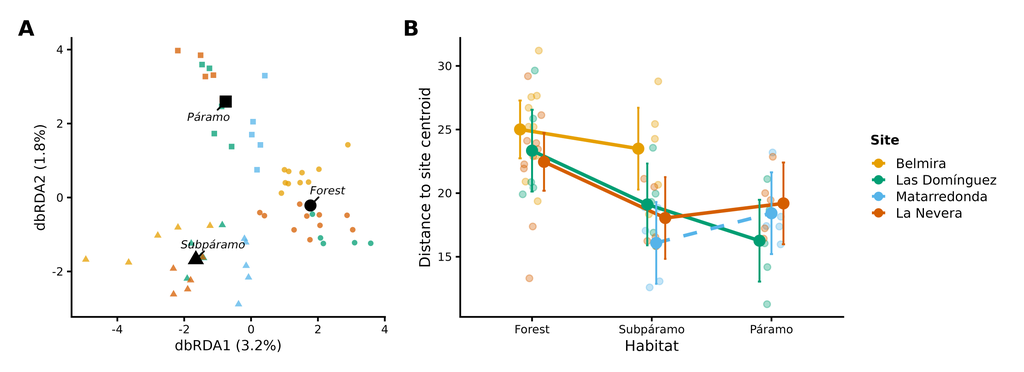

**Figure 2**: Community composition and turnover across habitats. Panel A: dbRDA ordination of RAF communities conditioned on site (color = site, shape = habitat; permutation $F=1.41$, $p=0.001$). Panel B: centroid-based turnover model (distance to site-specific centroid across habitats), with MA shown as dashed due to incomplete gradient (habitat adjusted for site $F_{2,54}=6.11$, $p=0.004$; habitat × site $F_{4,50}=1.28$, $p=0.29$).

## Section 5: Diversity trajectories

Diversity trajectories were assessed using three complementary approaches: per-plant Hill diversity models (rarefied to 28,122 reads) to test parallelism across sites, iNEXT3D rarefaction/extrapolation curves for habitat-level estimates with plants as sampling units, and beta-diversity partitioning. All analyses require a rooted phylogenetic tree, inferred below. Analyses are presented in computation order; Figure 3 follows as a composite of pre-computed outputs.

**Alignment and tree inference.** OTU reference sequences (ITS2; the 4,386 OTUs of the replicate-filtered, soil-subtracted root dataset, retaining both root replicates per plant) were aligned with the profile-to-profile aligner `AlignSeqs` in DECIPHER (Wright 2016), with sequence anchoring disabled (`anchor = NA`). No post-alignment curation, masking or trimming was applied. ITS2 is length-variable and hypervariable, so automated trimming heuristics discard a large share of the phylogenetically informative sites; and because the alignment is used only to derive a single fixed topology on which all samples are subsequently compared, alignment uncertainty enters every sample’s diversity estimate identically rather than differentially by habitat. A neighbour-joining tree built from maximum-likelihood distances (`dist.ml`) provided the starting topology, which was then optimised by maximum likelihood with `optim.pml` in phangorn (Schliep 2011) under GTR + Γ + I with four discrete rate categories, simultaneously optimising base frequencies, the rate matrix, branch lengths, the gamma shape parameter and the proportion of invariant sites, using stochastic rearrangements. The tree was inferred unrooted and midpoint-rooted (`phangorn::midpoint`) before use in phylogenetic diversity, NRI and NTI calculations.

**Substitution model.** GTR + Γ + I was adopted a priori rather than selected by a formal model-selection test, following the standard DADA2/phyloseq phylogenetic workflow (Callahan et al. 2016). It is the most parameter-rich time-reversible model available in `optim.pml`, so under-parameterisation is not a concern, and a formal model test across 4,386 ITS2 sequences was computationally prohibitive at this scale. All phylogenetic metrics reported here (phylogenetic Hill numbers as meanPD, NRI and NTI) are comparative statistics computed from relative branch lengths on this single shared topology, and are therefore expected to be robust to moderate differences in substitution model.

**Phylogenetic tree inference (GTR+Γ+I; executed on server)**

```r
library(DECIPHER)
library(Biostrings)
library(phangorn)
library(phyloseq)

# alldat.N[[2]]: rg2-filtered nopool root object retaining both
# root replicates per plant (120 samples); used for phylogenetic
# tree inference only. Equivalent to rg2.nopoolps before
# per-plant collapsing (ps_individual).
align <- AlignSeqs(DNAStringSet(refseq(alldat.N[[2]])), anchor=NA)

phang_align <- phyDat(as(align, "matrix"), type="DNA")
dm <- dist.ml(phang_align)
treeNJ <- NJ(dm)
fit <- pml(treeNJ, data=phang_align)
fitGTR <- update(fit, k=4, inv=0.2)
fit <- optim.pml(fitGTR, model="GTR", optInv=TRUE, optGamma=TRUE, optNni=FALSE,
                 optBf=TRUE, optQ=TRUE, optEdge=TRUE, optRooted=FALSE,
                 rearrangement = "stochastic", control = pml.control(trace = 0))

tree_data_rg2.N <- merge_phyloseq(alldat.N[[2]], fit$tree)

# Save for downstream use (loaded in Section 1 as tree_ps)
saveRDS(tree_data_rg2.N, file.path(out_obj_dir, "tree_ps.rds"))
```

### 5.1 Incidence-based beta-diversity partitioning (Table S11)

Sørensen dissimilarities were partitioned into turnover and nestedness-resultant components across taxonomic levels using the `betapart` package, on presence–absence data rarefied to 28,122 reads (the minimum observed library), retaining all 60 per-plant communities.

Table S11. Sørensen beta-diversity partitioning across taxonomic levels and sites. βSIM = turnover (taxon replacement), βSNE = nestedness-resultant component, βSOR = total Sørensen dissimilarity (βSIM + βSNE); N_units = number of taxonomic units resolved at that rank; Turnover_pct = βSIM as a percentage of βSOR. Computed with beta.multi() on presence–absence data rarefied to 28,122 reads.

| Site | Taxonomic_Level | N_units | beta.SIM | beta.SNE | beta.SOR | Turnover_pct |
| --- | --- | --- | --- | --- | --- | --- |
| DOM | OTU | 1158 | 0.9389 | 0.0147 | 0.9536 | 98.5 |
| DOM | Genus | 283 | 0.8366 | 0.0399 | 0.8764 | 95.5 |
| DOM | Order | 88 | 0.6998 | 0.0748 | 0.7746 | 90.3 |
| DOM | Class | 32 | 0.5562 | 0.1243 | 0.6805 | 81.7 |
| DOM | Phylum | 11 | 0.3737 | 0.2616 | 0.6353 | 58.8 |
| NV | OTU | 1607 | 0.9517 | 0.0133 | 0.9650 | 98.6 |
| NV | Genus | 333 | 0.8535 | 0.0454 | 0.8989 | 94.9 |
| NV | Order | 100 | 0.7333 | 0.0904 | 0.8236 | 89.0 |
| NV | Class | 38 | 0.6405 | 0.1188 | 0.7593 | 84.4 |
| NV | Phylum | 10 | 0.5153 | 0.1946 | 0.7099 | 72.6 |
| BEL | OTU | 1405 | 0.9300 | 0.0138 | 0.9438 | 98.5 |
| BEL | Genus | 286 | 0.8026 | 0.0464 | 0.8490 | 94.5 |
| BEL | Order | 96 | 0.6867 | 0.0823 | 0.7690 | 89.3 |
| BEL | Class | 37 | 0.5869 | 0.1094 | 0.6963 | 84.3 |
| BEL | Phylum | 12 | 0.3985 | 0.2444 | 0.6429 | 62.0 |
| MA | OTU | 594 | 0.9264 | 0.0131 | 0.9395 | 98.6 |
| MA | Genus | 145 | 0.7582 | 0.0638 | 0.8221 | 92.2 |
| MA | Order | 59 | 0.6234 | 0.0924 | 0.7159 | 87.1 |
| MA | Class | 21 | 0.3624 | 0.1873 | 0.5498 | 65.9 |
| MA | Phylum | 7 | 0.1818 | 0.2513 | 0.4331 | 42.0 |

### 5.2 iNEXT3D rarefaction curves and diversity summaries (Tables S12–S13b)

We quantified habitat-associated patterns in taxonomic diversity (TD) and phylogenetic diversity (PD) using iNEXT3D and Hill numbers (q = 0, 1, 2). Diversity estimates were computed from incidence (presence/absence) matrices at the habitat level, with plants as sampling units (an OTU is present in a plant if detected in either of its two root samples; 25, 20 and 15 plants in forest, subpáramo and páramo), and evaluated under rarefaction/extrapolation with bootstrap confidence intervals (nboot = 500). Phylogenetic diversity was estimated as meanPD (effective number of lineages) using a pruned phylogeny matched to the observed taxa. The combined curve visualization is presented in main-text Figure 3A; asymptotic summaries are provided in Tables S12–S13, coverage-standardised estimates in Table S13b, and the per-plant parallelism models in Tables S14–S15.

Sample coverage at the reference sample size is 0.58, 0.42 and 0.49 in forest, subpáramo and páramo, and 70–79% of the OTUs of each habitat are detected in a single plant, so the asymptotic estimates of Tables S12–S13 rest on a large undetected fraction and on habitats of unequal completeness. Habitats are therefore compared at a common sample coverage of 60% (Table S13b), the level iNEXT adopts by default: it is the coverage subpáramo attains at twice its observed number of plants, which is the recommended limit for extrapolation. Páramo is roughly half as diverse as forest and subpáramo for every metric and order, with non-overlapping confidence intervals. Forest and subpáramo do not differ in TD at any order (ratios 1.00–1.07, overlapping CIs) and differ only slightly in PD (ratios 1.04–1.21). Habitat-level diversity therefore follows forest ≈ subpáramo > páramo rather than a steady decline. Pairwise comparisons at 60% coverage are given in Table S13c.

Table S12. Taxonomic diversity (TD) summary from iNEXT3D across habitats with plants as sampling units (q = 0, 1, 2; nboot = 500). Observed and asymptotic estimates are reported with standard errors and 95% confidence intervals.

| Habitat | qTD | TD_obs | TD_asy | s.e. | qTD.LCL | qTD.UCL | Diversity_order |
| --- | --- | --- | --- | --- | --- | --- | --- |
| Forest | Species richness | 2521.000 | 6172.227 | 198.792 | 5782.601 | 6561.852 | Species richness |
| Forest | Shannon diversity | 1992.149 | 4148.349 | 91.922 | 3968.186 | 4328.513 | Shannon diversity |
| Forest | Simpson diversity | 1428.114 | 2101.863 | 56.685 | 1990.763 | 2212.963 | Simpson diversity |
| Páramo | Species richness | 901.000 | 2407.246 | 130.249 | 2151.962 | 2662.529 | Species richness |
| Páramo | Shannon diversity | 765.978 | 1859.858 | 75.676 | 1711.536 | 2008.180 | Shannon diversity |
| Páramo | Simpson diversity | 600.227 | 1051.258 | 50.412 | 952.452 | 1150.064 | Simpson diversity |
| Subpáramo | Species richness | 1533.000 | 4695.445 | 202.951 | 4297.668 | 5093.221 | Species richness |
| Subpáramo | Shannon diversity | 1340.805 | 3825.086 | 127.254 | 3575.673 | 4074.500 | Shannon diversity |
| Subpáramo | Simpson diversity | 1066.501 | 2128.877 | 93.427 | 1945.763 | 2311.990 | Simpson diversity |

Table S13. Phylogenetic diversity (PD; meanPD) summary from iNEXT3D across habitats with plants as sampling units (q = 0, 1, 2; nboot = 500). Observed and asymptotic effective numbers of lineages are reported with standard errors and 95% confidence intervals.

| Habitat | qPD | PD_obs | PD_asy | s.e. | qPD.LCL | qPD.UCL | Reftime | Type |
| --- | --- | --- | --- | --- | --- | --- | --- | --- |
| Forest | q = 0 PD | 185.553 | 326.866 | 10.346 | 306.589 | 347.144 | 0.873 | meanPD |
| Forest | q = 1 PD | 112.466 | 148.345 | 2.022 | 144.382 | 152.308 | 0.873 | meanPD |
| Forest | q = 2 PD | 70.612 | 77.842 | 0.815 | 76.244 | 79.439 | 0.873 | meanPD |
| Páramo | q = 0 PD | 81.971 | 143.212 | 6.652 | 130.173 | 156.250 | 0.873 | meanPD |
| Páramo | q = 1 PD | 56.100 | 80.094 | 1.874 | 76.420 | 83.767 | 0.873 | meanPD |
| Páramo | q = 2 PD | 37.576 | 43.701 | 0.821 | 42.093 | 45.310 | 0.873 | meanPD |
| Subpáramo | q = 0 PD | 132.936 | 246.757 | 10.004 | 227.149 | 266.364 | 0.873 | meanPD |
| Subpáramo | q = 1 PD | 88.309 | 130.400 | 2.673 | 125.161 | 135.638 | 0.873 | meanPD |
| Subpáramo | q = 2 PD | 54.604 | 63.591 | 0.974 | 61.682 | 65.500 | 0.873 | meanPD |

Table S13b. Coverage-standardised taxonomic (TD) and phylogenetic (PD; meanPD) diversity by habitat at 60% sample coverage, with plants as sampling units (q = 0, 1, 2; nboot = 500). Estimates are reported with bootstrap standard errors and 95% confidence limits.

| diversity | q | habitat | estimate | se | lcl | ucl | coverage |
| --- | --- | --- | --- | --- | --- | --- | --- |
| TD | 0 | forest | 2710.135 | 69.099 | 2574.704 | 2845.566 | 0.6 |
| TD | 1 | forest | 2105.809 | 49.605 | 2008.585 | 2203.033 | 0.6 |
| TD | 2 | forest | 1475.376 | 34.114 | 1408.513 | 1542.239 | 0.6 |
| TD | 0 | subparamo | 2532.624 | 102.558 | 2331.615 | 2733.634 | 0.6 |
| TD | 1 | subparamo | 2104.899 | 80.148 | 1947.811 | 2261.987 | 0.6 |
| TD | 2 | subparamo | 1421.084 | 53.180 | 1316.852 | 1525.316 | 0.6 |
| TD | 0 | paramo | 1229.433 | 52.810 | 1125.928 | 1332.939 | 0.6 |
| TD | 1 | paramo | 999.084 | 38.746 | 923.143 | 1075.026 | 0.6 |
| TD | 2 | paramo | 708.818 | 25.987 | 657.883 | 759.752 | 0.6 |
| PD | 0 | forest | 195.707 | 3.520 | 188.809 | 202.606 | 0.6 |
| PD | 1 | forest | 115.492 | 1.488 | 112.576 | 118.409 | 0.6 |
| PD | 2 | forest | 71.273 | 0.715 | 69.872 | 72.674 | 0.6 |
| PD | 0 | subparamo | 188.822 | 4.775 | 179.463 | 198.181 | 0.6 |
| PD | 1 | subparamo | 110.342 | 2.095 | 106.236 | 114.448 | 0.6 |
| PD | 2 | subparamo | 58.756 | 0.820 | 57.149 | 60.362 | 0.6 |
| PD | 0 | paramo | 102.308 | 3.132 | 96.169 | 108.447 | 0.6 |
| PD | 1 | paramo | 64.378 | 1.441 | 61.554 | 67.202 | 0.6 |
| PD | 2 | paramo | 39.556 | 0.691 | 38.201 | 40.911 | 0.6 |

Table S13c. Pairwise habitat comparisons of coverage-standardised diversity (60% coverage; plants as sampling units). Est. 1 and Est. 2 are the estimates for the first and second habitat of each pair, Ratio = Est. 1 / Est. 2, CIs overlap indicates whether the two 95% bootstrap confidence intervals overlap, and z and p (Holm) are from a z-test on the bootstrap standard errors, Holm-adjusted across the three pairs.

| Diversity | q | Pair | Est. 1 | Est. 2 | Ratio | CIs overlap | z | p (Holm) |
| --- | --- | --- | --- | --- | --- | --- | --- | --- |
| PD | 0 | Forest vs Páramo | 195.707 | 102.308 | 1.913 | FALSE | 19.823 | 0.000 |
| PD | 0 | Forest vs Subpáramo | 195.707 | 188.822 | 1.036 | TRUE | 1.161 | 0.246 |
| PD | 0 | Subpáramo vs Páramo | 188.822 | 102.308 | 1.846 | FALSE | 15.150 | 0.000 |
| PD | 1 | Forest vs Páramo | 115.492 | 64.378 | 1.794 | FALSE | 24.678 | 0.000 |
| PD | 1 | Forest vs Subpáramo | 115.492 | 110.342 | 1.047 | TRUE | 2.004 | 0.045 |
| PD | 1 | Subpáramo vs Páramo | 110.342 | 64.378 | 1.714 | FALSE | 18.078 | 0.000 |
| PD | 2 | Forest vs Páramo | 71.273 | 39.556 | 1.802 | FALSE | 31.893 | 0.000 |
| PD | 2 | Forest vs Subpáramo | 71.273 | 58.756 | 1.213 | FALSE | 11.510 | 0.000 |
| PD | 2 | Subpáramo vs Páramo | 58.756 | 39.556 | 1.485 | FALSE | 17.904 | 0.000 |
| TD | 0 | Forest vs Páramo | 2710.135 | 1229.433 | 2.204 | FALSE | 17.026 | 0.000 |
| TD | 0 | Forest vs Subpáramo | 2710.135 | 2532.624 | 1.070 | TRUE | 1.435 | 0.151 |
| TD | 0 | Subpáramo vs Páramo | 2532.624 | 1229.433 | 2.060 | FALSE | 11.297 | 0.000 |
| TD | 1 | Forest vs Páramo | 2105.809 | 999.084 | 2.108 | FALSE | 17.583 | 0.000 |
| TD | 1 | Forest vs Subpáramo | 2105.809 | 2104.899 | 1.000 | TRUE | 0.010 | 0.992 |
| TD | 1 | Subpáramo vs Páramo | 2104.899 | 999.084 | 2.107 | FALSE | 12.422 | 0.000 |
| TD | 2 | Forest vs Páramo | 1475.376 | 708.818 | 2.081 | FALSE | 17.875 | 0.000 |
| TD | 2 | Forest vs Subpáramo | 1475.376 | 1421.084 | 1.038 | TRUE | 0.859 | 0.390 |
| TD | 2 | Subpáramo vs Páramo | 1421.084 | 708.818 | 2.005 | FALSE | 12.033 | 0.000 |

**iNEXT3D diversity analyses (Scripts/iNEXT3D_plant_level.R)**

```r
# Habitat-level iNEXT3D with PLANTS as incidence units. Run from the repository root:
#   Rscript Scripts/iNEXT3D_plant_level.R
#
# Inputs : objects/ps_individual.rds (root samples summed per plant)
#          objects/tree_ps.rds       (ML tree; pruned to the shared taxa, midpoint-rooted)
# Settings: q = 0, 1, 2; datatype = "incidence_raw"; nboot = 500; seed = 1; PDtype = "meanPD";
#           coverage-standardised estimates at the plant-unit Cmin (60% coverage)
#
# Key outputs saved:
#   - tables/Table_S16_iNEXT3D_TD_plant.csv            (Table S12)
#   - tables/Table_S17_iNEXT3D_PD_plant.csv            (Table S13)
#   - tables/iNEXT3D_estimates_plant_vs_root.csv       (Table S13b; plus root-sample units for comparison)
#   - tables/iNEXT3D_pairwise_habitat_plant_vs_root.csv (pairwise habitat comparisons)
#   - objects/out_TD_plant.rds, objects/out_PD_plant.rds (Figure 3A)
```

### 5.3 Per-plant Hill diversity: parallelism models (Tables S14–S15)

To evaluate whether diversity trajectories are parallel across geographically isolated sites, we model diversity as a function of habitat (ordered along elevation) and site, each tested adjusted for the other, and test the habitat × site interaction by comparing the additive and interaction models, cross-checked against AICc. The interaction test is itself the parallelism result, and it determines which model the habitat effects are then read from: where the interaction is not supported the additive model is retained and habitat is reported marginally, and where it is supported there is no common trajectory and habitat effects are reported within sites. The same rule is applied to all six responses.

For this section, diversity is computed independently for each plant using Hill numbers of taxonomic diversity (TD) and phylogenetic diversity (PD; meanPD) at q = 0, 1 and 2, after rarefying every plant to 28,122 reads (the smallest library) with `iNEXT.3D::estimate3D`. Coverage-based standardisation is not informative here: no plant retains a singleton OTU after the 2-of-4 replicate filter, so coverage is ≥ 0.999 at any depth.

Models are gamma GLMs with a log link, so habitat effects are ratios of effective diversity; gamma had the lowest summed AICc in a Jacobian-corrected screen against Gaussian and log-normal models, and habitat results were refitted under all three families as a sensitivity check.

Adjusted for site, habitat affects per-plant richness (TD q = 0: $F_{2,54}=9.21$, $p=0.0004$; PD q = 0: $F_{2,54}=9.61$, $p=0.0003$), with the pairwise contrasts reported below (Table S15b). The habitat effect is still present at q = 1 (TD $F_{2,54}=3.21$, $p=0.048$; AICc also retains habitat, ΔAICc −2.0), though no pairwise contrast resolves there, and it is gone by q = 2 (TD $p=0.15$). The habitat × site interaction is absent for TD at every order ($p=0.22$–$0.25$) and for PD at q = 0 ($p=0.42$), but present for abundance-weighted PD (q = 1: $F_{4,50}=3.81$, $p=0.009$; q = 2: $F_{4,50}=7.27$, $p=0.0001$), where it is driven by the single forest location at Las Domínguez. AICc agrees with every one of these decisions: across the site-only, additive and interaction gamma models, the additive model carries Akaike weights of 0.94 (TD q = 0) and 0.98 (PD q = 0), while at PD q = 1 and q = 2 the interaction model carries 0.95 and 1.00 (Table S21).

**Post-hoc pairwise habitat contrasts (Table S15b).** Habitat is a categorical predictor, so the omnibus *F*-test for the habitat term establishes that habitats differ but does not identify which pairs differ, or in which direction. We therefore followed it with pairwise contrasts among the three habitats, taken from the same additive model as the omnibus test (gamma GLM with a log link, diversity ~ habitat + site) and Tukey-adjusted for the three comparisons. Taking both tests from one model matters: in the published version the omnibus test was sequential (Type I, habitat entered before site and therefore not adjusted for it) while the contrasts came from the additive model, so the two asked different questions and a significant habitat term could sit alongside no resolved pair. The full design also contains empty habitat × site cells (Matarredonda has no forest, Belmira no páramo), which makes habitat marginal means non-estimable from the interaction model. Contrasts are reported on the response scale as ratios of effective diversity, so a ratio above one indicates higher diversity in the first habitat.

The per-plant decline is concentrated at the forest boundary. At q = 0 both forest contrasts are resolved for each metric (TD forest/subpáramo 1.52, *p* = 0.0005; forest/páramo 1.69, *p* = 0.0002; PD 1.39, *p* = 0.001 and 1.58, *p* = 0.0001), while subpáramo and páramo do not differ (TD 1.11, *p* = 0.64; PD 1.13, *p* = 0.40): marginal richness falls from forest (TD 146.9, PD 20.1) to subpáramo (96.6, 14.4) and páramo (87.1, 12.7), with the second step flat. At q = 1 the direction is the same but nothing resolves (TD forest/subpáramo 1.48, *p* = 0.055; forest/páramo 1.53, *p* = 0.078), and at q = 2 no TD contrast is resolved at all. Polynomial contrasts across the ordered habitats are significant for TD at q = 0 (*p* < 0.0001) and q = 1 (*p* = 0.031) and for PD at q = 0 (*p* = 0.00004), so diversity does fall along the gradient — but as one step at the treeline rather than a stepwise decline across successive habitats.

For abundance-weighted PD (q = 1–2) the habitat × site interaction is supported (Table S15), so no common habitat trajectory applies and neither the marginal contrasts nor the polynomial trends of the additive model are inferential there; the corresponding rows of Table S15b are reported for completeness only. From the interaction model, the habitat effect at these orders is confined to Las Domínguez, where forest plants exceed subpáramo (q = 1: 1.69×, *p* = 0.002; q = 2: 1.62×, *p* < 0.001) and páramo (1.81×, *p* = 0.0004; 1.55×, *p* < 0.001), while no habitat contrast is resolved at any other site. Per-habitat sample sizes for pairwise inference remain small (n = 25, 20 and 15 plants for forest, subpáramo and páramo).

**Which site drives the PD interaction.** The interaction at q = 1–2 disappears only when Las Domínguez is dropped (q = 1: $p=0.18$; q = 2: $p=0.23$), stays significant or borderline ($p \le 0.054$) when any other site is dropped, and is strong within the two complete gradients alone (NV + DOM: $p=0.012$ and $p=0.0001$; Table S15c). Las Domínguez forest plants have abundance-weighted PD of 2.21 (q = 1), against 1.43–1.44 in the other forests, and then fall to subpáramo and páramo levels; every other site is flat (Figure S3b, Table S15d). The pattern is not one unusual plant: removing influential plants (Cook’s distance) leaves it significant ($p=0.029$ at q = 1; $p=0.0004$ at q = 2). It is partly linked to Helotiales dominance, which predicts lower abundance-weighted PD at q = 2 ($p<0.001$; not at q = 1, $p=0.18$); adding it as a covariate reduces the q = 2 interaction from $F=7.27$ to $F=4.51$ ($p=0.0035$; Table S15e). Because Las Domínguez forest is a single location (DOM_3), this site-dependence cannot be separated from a stand effect. TD, by contrast, is parallel between the two complete gradients at every order (NV + DOM, all $p \ge 0.34$).

This differs from the habitat-level pattern in Section 5.2, where forest and subpáramo are indistinguishable and páramo is clearly the poorest assemblage: per plant the break is at the forest boundary, per habitat it is at the páramo boundary. The two are consistent if subpáramo plants are individually poorer than forest plants but more different from one another, so that the habitat total keeps pace with forest, while páramo plants are individually as rich as subpáramo plants but more alike. This comparison is qualitative only, since the per-plant values are abundance-based and the habitat-level values incidence-based.

Table S14. Tests for per-plant taxonomic diversity (TD; Hill q = 0, 1, 2; rarefied to 28,122 reads) from gamma GLMs (log link): habitat and site each adjusted for the other (additive model), and the habitat × site interaction by model comparison. The interaction is not significant at any order (p = 0.22–0.25), supporting parallel TD trajectories across sites.

| diversity | q | term | df1 | df2 | F | p |
| --- | --- | --- | --- | --- | --- | --- |
| TD | 0 | habitat x site (parallelism) | 4 | 50 | 1.4977 | 0.2171 |
| TD | 0 | habitat (adjusted for site) | 2 | 54 | 9.2123 | 0.0004 |
| TD | 0 | site (adjusted for habitat) | 3 | 54 | 0.8080 | 0.4950 |
| TD | 1 | habitat x site (parallelism) | 4 | 50 | 1.4319 | 0.2372 |
| TD | 1 | habitat (adjusted for site) | 2 | 54 | 3.2076 | 0.0483 |
| TD | 1 | site (adjusted for habitat) | 3 | 54 | 0.4513 | 0.7175 |
| TD | 2 | habitat x site (parallelism) | 4 | 50 | 1.4023 | 0.2468 |
| TD | 2 | habitat (adjusted for site) | 2 | 54 | 1.9999 | 0.1453 |
| TD | 2 | site (adjusted for habitat) | 3 | 54 | 0.2829 | 0.8375 |

Table S15. Tests for per-plant phylogenetic diversity (PD; meanPD; Hill q = 0, 1, 2; rarefied to 28,122 reads) from gamma GLMs (log link): habitat and site each adjusted for the other (additive model), and the habitat × site interaction by model comparison. The interaction is not significant at q = 0 (p = 0.42) but is at q = 1 (p = 0.009) and q = 2 (p = 0.0001), driven by Las Domínguez.

| diversity | q | term | df1 | df2 | F | p |
| --- | --- | --- | --- | --- | --- | --- |
| PD | 0 | habitat x site (parallelism) | 4 | 50 | 1.0012 | 0.4158 |
| PD | 0 | habitat (adjusted for site) | 2 | 54 | 9.6132 | 0.0003 |
| PD | 0 | site (adjusted for habitat) | 3 | 54 | 0.6139 | 0.6089 |
| PD | 1 | habitat x site (parallelism) | 4 | 50 | 3.8086 | 0.0089 |
| PD | 1 | habitat (adjusted for site) | 2 | 54 | 4.0743 | 0.0225 |
| PD | 1 | site (adjusted for habitat) | 3 | 54 | 3.3884 | 0.0244 |
| PD | 2 | habitat x site (parallelism) | 4 | 50 | 7.2732 | 0.0001 |
| PD | 2 | habitat (adjusted for site) | 2 | 54 | 4.5366 | 0.0151 |
| PD | 2 | site (adjusted for habitat) | 3 | 54 | 6.5005 | 0.0008 |

Table S15b. Post-hoc pairwise contrasts among habitats for per-plant Hill diversity (q = 0, 1, 2; rarefied to 28,122 reads), for taxonomic (TD) and phylogenetic (PD; meanPD) diversity. Contrasts come from the same additive model as the omnibus tests in Tables S14–S15 (gamma GLM with a log link, diversity ~ habitat + site) and are Tukey-adjusted for three comparisons; the additive model is used because the full design contains empty habitat × site cells, which makes habitat marginal means non-estimable from the interaction model. Estimates are on the response scale: ratio is the multiplicative difference in effective diversity between the two habitats (ratio > 1 = higher diversity in the first habitat), with 95% confidence limits. For PD at q = 1 and q = 2 the habitat × site interaction is supported (Table S15), so the additive model does not describe those orders and their rows are descriptive rather than inferential.

| diversity | q | contrast | ratio | SE | df | lower.CL | upper.CL | t.ratio | p.value |
| --- | --- | --- | --- | --- | --- | --- | --- | --- | --- |
| TD | 0 | forest / subparamo | 1.5204 | 0.1590 | 54 | 1.1817 | 1.9562 | 4.0065 | 0.0005 |
| TD | 0 | forest / paramo | 1.6864 | 0.2047 | 54 | 1.2586 | 2.2595 | 4.3045 | 0.0002 |
| TD | 0 | subparamo / paramo | 1.1092 | 0.1280 | 54 | 0.8399 | 1.4647 | 0.8980 | 0.6439 |
| TD | 1 | forest / subparamo | 1.4781 | 0.2438 | 54 | 0.9933 | 2.1996 | 2.3694 | 0.0549 |
| TD | 1 | forest / paramo | 1.5270 | 0.2924 | 54 | 0.9626 | 2.4225 | 2.2108 | 0.0784 |
| TD | 1 | subparamo / paramo | 1.0331 | 0.1880 | 54 | 0.6663 | 1.6018 | 0.1788 | 0.9825 |
| TD | 2 | forest / subparamo | 1.4229 | 0.2573 | 54 | 0.9203 | 2.2001 | 1.9506 | 0.1346 |
| TD | 2 | forest / paramo | 1.3258 | 0.2783 | 54 | 0.7994 | 2.1989 | 1.3435 | 0.3777 |
| TD | 2 | subparamo / paramo | 0.9318 | 0.1859 | 54 | 0.5761 | 1.5070 | -0.3542 | 0.9333 |
| PD | 0 | forest / subparamo | 1.3936 | 0.1220 | 54 | 1.1285 | 1.7210 | 3.7907 | 0.0011 |
| PD | 0 | forest / paramo | 1.5813 | 0.1607 | 54 | 1.2377 | 2.0202 | 4.5084 | 0.0001 |
| PD | 0 | subparamo / paramo | 1.1347 | 0.1096 | 54 | 0.8990 | 1.4321 | 1.3082 | 0.3969 |
| PD | 1 | forest / subparamo | 1.1801 | 0.0982 | 54 | 0.9656 | 1.4422 | 1.9897 | 0.1245 |
| PD | 1 | forest / paramo | 1.2653 | 0.1223 | 54 | 1.0024 | 1.5970 | 2.4348 | 0.0472 |
| PD | 1 | subparamo / paramo | 1.0721 | 0.0985 | 54 | 0.8593 | 1.3377 | 0.7585 | 0.7298 |
| PD | 2 | forest / subparamo | 1.1620 | 0.0639 | 54 | 1.0179 | 1.3266 | 2.7329 | 0.0227 |
| PD | 2 | forest / paramo | 1.1453 | 0.0731 | 54 | 0.9821 | 1.3356 | 2.1263 | 0.0940 |
| PD | 2 | subparamo / paramo | 0.9856 | 0.0598 | 54 | 0.8516 | 1.1406 | -0.2396 | 0.9689 |

Table S15c. Habitat × site interaction tests for per-plant TD and PD (gamma GLMs, log link) with all sites, with each site left out in turn, and within the two complete gradients (NV + DOM). df1 and df2 are the numerator and denominator degrees of freedom of the model-comparison F-test.

| Diversity | q | Sites | Plants | df1 | df2 | F | p |
| --- | --- | --- | --- | --- | --- | --- | --- |
| TD | 0 | all sites | 60 | 4 | 50 | 1.4977 | 0.2171 |
| TD | 0 | without BEL | 45 | 3 | 37 | 1.7225 | 0.1792 |
| TD | 0 | without DOM | 45 | 2 | 38 | 0.8523 | 0.4344 |
| TD | 0 | without MA | 50 | 3 | 42 | 0.8456 | 0.4768 |
| TD | 0 | without NV | 40 | 2 | 33 | 2.9110 | 0.0685 |
| TD | 0 | NV + DOM only (complete gradients) | 35 | 2 | 29 | 1.1115 | 0.3427 |
| TD | 1 | all sites | 60 | 4 | 50 | 1.4319 | 0.2372 |
| TD | 1 | without BEL | 45 | 3 | 37 | 1.3768 | 0.2650 |
| TD | 1 | without DOM | 45 | 2 | 38 | 1.7771 | 0.1829 |
| TD | 1 | without MA | 50 | 3 | 42 | 0.2451 | 0.8644 |
| TD | 1 | without NV | 40 | 2 | 33 | 3.1956 | 0.0539 |
| TD | 1 | NV + DOM only (complete gradients) | 35 | 2 | 29 | 0.1824 | 0.8342 |
| TD | 2 | all sites | 60 | 4 | 50 | 1.4023 | 0.2468 |
| TD | 2 | without BEL | 45 | 3 | 37 | 1.0654 | 0.3755 |
| TD | 2 | without DOM | 45 | 2 | 38 | 2.0967 | 0.1368 |
| TD | 2 | without MA | 50 | 3 | 42 | 0.6462 | 0.5897 |
| TD | 2 | without NV | 40 | 2 | 33 | 2.5147 | 0.0963 |
| TD | 2 | NV + DOM only (complete gradients) | 35 | 2 | 29 | 0.3796 | 0.6875 |
| PD | 0 | all sites | 60 | 4 | 50 | 1.0012 | 0.4158 |
| PD | 0 | without BEL | 45 | 3 | 37 | 1.0640 | 0.3761 |
| PD | 0 | without DOM | 45 | 2 | 38 | 0.5845 | 0.5623 |
| PD | 0 | without MA | 50 | 3 | 42 | 0.7078 | 0.5528 |
| PD | 0 | without NV | 40 | 2 | 33 | 1.8238 | 0.1773 |
| PD | 0 | NV + DOM only (complete gradients) | 35 | 2 | 29 | 0.8687 | 0.4301 |
| PD | 1 | all sites | 60 | 4 | 50 | 3.8086 | 0.0089 |
| PD | 1 | without BEL | 45 | 3 | 37 | 4.2951 | 0.0107 |
| PD | 1 | without DOM | 45 | 2 | 38 | 1.7848 | 0.1816 |
| PD | 1 | without MA | 50 | 3 | 42 | 4.2477 | 0.0104 |
| PD | 1 | without NV | 40 | 2 | 33 | 3.2408 | 0.0519 |
| PD | 1 | NV + DOM only (complete gradients) | 35 | 2 | 29 | 5.2145 | 0.0116 |
| PD | 2 | all sites | 60 | 4 | 50 | 7.2732 | 0.0001 |
| PD | 2 | without BEL | 45 | 3 | 37 | 9.4589 | 0.0001 |
| PD | 2 | without DOM | 45 | 2 | 38 | 1.5466 | 0.2261 |
| PD | 2 | without MA | 50 | 3 | 42 | 9.0070 | 0.0001 |
| PD | 2 | without NV | 40 | 2 | 33 | 5.4467 | 0.0090 |
| PD | 2 | NV + DOM only (complete gradients) | 35 | 2 | 29 | 12.7322 | 0.0001 |

Table S15d. Within-site habitat contrasts for abundance-weighted PD (q = 1, 2) from the habitat × site interaction model (gamma GLM, log link), as ratios of effective diversity with 95% confidence limits and Tukey-adjusted p-values within each site. Only contrasts estimable within a site are shown (BEL has no páramo, MA no forest).

| Diversity | q | Site | Contrast | Ratio | Lower CL | Upper CL | p |
| --- | --- | --- | --- | --- | --- | --- | --- |
| PD | 1 | BEL | forest / subparamo | 1.1129 | 0.8678 | 1.4273 | 0.3919 |
| PD | 1 | DOM | forest / subparamo | 1.6934 | 1.1987 | 2.3922 | 0.0016 |
| PD | 1 | DOM | forest / paramo | 1.8086 | 1.2803 | 2.5550 | 0.0004 |
| PD | 1 | DOM | subparamo / paramo | 1.0681 | 0.7560 | 1.5088 | 0.8900 |
| PD | 1 | MA | subparamo / paramo | 0.9135 | 0.6854 | 1.2175 | 0.5298 |
| PD | 1 | NV | forest / subparamo | 0.9031 | 0.6695 | 1.2180 | 0.6905 |
| PD | 1 | NV | forest / paramo | 1.0829 | 0.8028 | 1.4606 | 0.7973 |
| PD | 1 | NV | subparamo / paramo | 1.1991 | 0.8488 | 1.6940 | 0.4188 |
| PD | 2 | BEL | forest / subparamo | 1.1227 | 0.9638 | 1.3078 | 0.1341 |
| PD | 2 | DOM | forest / subparamo | 1.6167 | 1.3079 | 1.9983 | 0.0000 |
| PD | 2 | DOM | forest / paramo | 1.5542 | 1.2573 | 1.9211 | 0.0000 |
| PD | 2 | DOM | subparamo / paramo | 0.9613 | 0.7777 | 1.1883 | 0.8949 |
| PD | 2 | MA | subparamo / paramo | 1.0303 | 0.8638 | 1.2288 | 0.7353 |
| PD | 2 | NV | forest / subparamo | 0.9722 | 0.8092 | 1.1680 | 0.9269 |
| PD | 2 | NV | forest / paramo | 0.9195 | 0.7653 | 1.1047 | 0.5156 |
| PD | 2 | NV | subparamo / paramo | 0.9458 | 0.7652 | 1.1691 | 0.8015 |

Table S15e. Habitat × site interaction for abundance-weighted PD (q = 1, 2; n = 60 plants) with and without the logit relative abundance of Helotiales and/or Sebacinales as a covariate. Helot./Sebac. slope and p give the association of each lineage with per-plant PD; df1, df2, F and p are for the interaction term under each covariate set.

| q | Covariate | Helot. slope | Helot. p | Sebac. slope | Sebac. p | df1 | df2 | F | p |
| --- | --- | --- | --- | --- | --- | --- | --- | --- | --- |
| 1 | none | -0.0528 | 0.1778 | 0.0183 | 0.5269 | 4 | 50 | 3.8086 | 0.0089 |
| 1 | Helotiales (logit) | -0.0528 | 0.1778 | 0.0183 | 0.5269 | 4 | 49 | 3.1888 | 0.0209 |
| 1 | Sebacinales (logit) | -0.0528 | 0.1778 | 0.0183 | 0.5269 | 4 | 49 | 3.6037 | 0.0118 |
| 1 | Helotiales + Sebacinales | -0.0528 | 0.1778 | 0.0183 | 0.5269 | 4 | 48 | 3.1103 | 0.0235 |
| 2 | none | -0.1035 | 0.0000 | 0.0501 | 0.0061 | 4 | 50 | 7.2732 | 0.0001 |
| 2 | Helotiales (logit) | -0.1035 | 0.0000 | 0.0501 | 0.0061 | 4 | 49 | 4.5121 | 0.0035 |
| 2 | Sebacinales (logit) | -0.1035 | 0.0000 | 0.0501 | 0.0061 | 4 | 49 | 6.3254 | 0.0003 |
| 2 | Helotiales + Sebacinales | -0.1035 | 0.0000 | 0.0501 | 0.0061 | 4 | 48 | 4.2610 | 0.0050 |

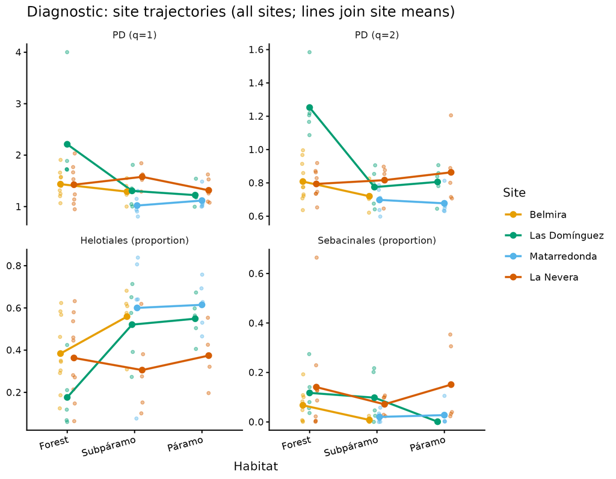

**Figure S3b**: Site trajectories across habitats for per-plant abundance-weighted phylogenetic diversity (PD, meanPD; q = 1 and q = 2; rarefied to 28,122 reads) and for Helotiales and Sebacinales relative abundance. Small points are individual plants; large points joined by lines are site means. The PD interaction is driven by the single Las Domínguez forest location (DOM_3). *Code: Scripts/parallelism_diagnostics.R.*

**Per-plant Hill TD/PD: rarefaction, habitat and parallelism models (Scripts/perplant_hill_size_standardised.R)**

```r
# Per-plant Hill numbers and habitat/parallelism tests. Run from the repository root:
#   Rscript Scripts/perplant_hill_size_standardised.R   (FAMILY <- "gamma_log")
#   Rscript Scripts/parallelism_diagnostics.R           (leave-one-site-out, DOM trajectories)
#   Rscript Scripts/family_sensitivity.R                (gaussian / lognormal / gamma refits)
#   Rscript Scripts/model_selection_aicc.R              (AIC/AICc/BIC, Jacobian-corrected family screen)
#
# Inputs : objects/ps_individual.rds, objects/tree_ps.rds
# Method : every plant rarefied to 28,122 reads with iNEXT.3D::estimate3D (TD and meanPD, q = 0, 1, 2);
#          habitat and site tested adjusted for each other (additive model); habitat x site by
#          model comparison; Tukey contrasts from the additive model.
#
# Key outputs saved:
#   - tables/perplant_hill_size_std_omnibus.csv   (Tables S14-S15)
#   - tables/perplant_hill_size_std_pairwise.csv, _emmeans.csv, _trend.csv, _values.csv
#   - tables/diag_leave_one_site_out.csv, diag_within_site_contrasts.csv,
#     diag_PD_interaction_vs_lineages.csv, diag_influential_plants_PD.csv (Tables S15c-e)
#   - figures/diag_parallelism_sites.png                                    (Figure S3b)
#   - tables/family_sensitivity_*.csv, model_selection_aicc.csv
#   - objects/perplant_hill_size_std.rds          (Figure 3B)
```

### 5.4 Figure 3: Diversity trajectories

[figure not shown]

**Figure 3**: Diversity across the elevational gradient. Panel A shows iNEXT3D coverage-based rarefaction/extrapolation curves for TD and PD (meanPD) at $q=0,1,2$ by habitat, with plants as sampling units; páramo is lower than forest and subpáramo, which overlap. Panel B shows per-plant Hill diversity (rarefied to 28,122 reads) at $q=0,1,2$ for TD and PD, with model-estimated means ± 95% CI for BEL, DOM, and NV (MA excluded). Habitat × site interactions were non-significant for TD at every order and for PD at $q=0$, but significant for PD at $q=1$ ($F_{4,50}=3.81$, $p=0.009$) and $q=2$ ($F_{4,50}=7.27$, $p=0.0001$), driven by Las Domínguez.

**Code used to generate Figure 3 (Scripts/iNEXT3D_plant_level.R + Scripts/perplant_hill_size_standardised.R)**

```r
# Figure 3 is assembled by the two scripts of Sections 5.2-5.3 (run from the repository root):
#   Rscript Scripts/iNEXT3D_plant_level.R              -> Panel A (plants as incidence units)
#   Rscript Scripts/perplant_hill_size_standardised.R  -> Panel B and the combined figure
#
# Key outputs saved:
#   - figures/Figure_3A_iNEXT_plant_units.png, objects/Figure_3A_panel_plant_units.rds
#   - figures/Figure_3B_perplant_size_std.png, objects/Figure_3B_panel_size_std.rds
#   - figures/Figure_3_corrected.png   (embedded above)
```

## Section 6: Lineage-specific responses

### 6.1 Beta regression models (Tables S16–S18)

To quantify elevational trends in the relative abundance of dominant fungal lineages, we fitted beta-regression models to order-level relative read abundances. Models were fitted separately for each order using a logit link, with elevation as a continuous predictor and site included as a fixed effect. Relative abundances were calculated as proportions of total reads per plant (n = 60) and transformed using a Smithson–Verkuilen adjustment.

We focus on helotiales and sebacinales, the two most abundant orders, which also showed the only significant elevation responses. For both orders, fitted relationships and raw data are shown in Figure 4 (Panels A-B), while full model summaries are provided in Tables S16 and S17. Elevation effects for the eight most abundant orders are summarized in Table S18.

Model diagnostics were examined to assess fit and identify potential violations of distributional assumptions. Diagnostic plots include Pearson residuals versus fitted values and elevation, quantile residual Q–Q plots, and leverage values (Figures S4–S5).

Table S16. Beta regression summary for Helotiales (mean model coefficients and precision (phi)).

| Model | Term | Estimate | SE | z | p |
| --- | --- | --- | --- | --- | --- |
| helotiales | (Intercept) | -3.2040 | 1.2559 | -2.5512 | 0.0107 |
| helotiales | elevation | 0.0010 | 0.0004 | 2.3959 | 0.0166 |
| helotiales | siteDOM | -0.7291 | 0.3651 | -1.9969 | 0.0458 |
| helotiales | siteMA | 0.0050 | 0.3871 | 0.0130 | 0.9896 |
| helotiales | siteNV | -0.8864 | 0.3346 | -2.6494 | 0.0081 |
| helotiales | (phi) (phi) | 6.2698 | 1.0711 | 5.8534 | 0.0000 |

Table S17. Beta regression summary for Sebacinales (mean model coefficients and precision (phi)).

| Model | Term | Estimate | SE | z | p |
| --- | --- | --- | --- | --- | --- |
| sebacinales | (Intercept) | 0.4169 | 1.3941 | 0.2990 | 0.7649 |
| sebacinales | elevation | -0.0010 | 0.0005 | -2.1320 | 0.0330 |
| sebacinales | siteDOM | 0.7196 | 0.4162 | 1.7289 | 0.0838 |
| sebacinales | siteMA | 0.3029 | 0.4603 | 0.6580 | 0.5105 |
| sebacinales | siteNV | 0.9779 | 0.3714 | 2.6333 | 0.0085 |
| sebacinales | (phi) (phi) | 10.1810 | 2.0241 | 5.0298 | 0.0000 |

Table S18. Elevation effects from beta regression models for the dominant orders (mean submodel), with pseudo-R².

| order | term | estimate | se | z | p_value | pseudo_R2 |
| --- | --- | --- | --- | --- | --- | --- |
| helotiales | elevation | 1e-03 | 4e-04 | 2.3959 | 0.0166 | 0.2133 |
| sebacinales | elevation | -1e-03 | 5e-04 | -2.1320 | 0.0330 | 0.2261 |
| chaetothyriales | elevation | 1e-04 | 4e-04 | 0.2327 | 0.8160 | 0.0239 |
| sclerococcales | elevation | 7e-04 | 5e-04 | 1.3758 | 0.1689 | 0.1330 |
| agaricales | elevation | -7e-04 | 4e-04 | -1.7597 | 0.0785 | 0.0929 |
| pleosporales | elevation | -4e-04 | 4e-04 | -1.0668 | 0.2861 | 0.1528 |
| hypocreales | elevation | -2e-04 | 3e-04 | -0.7300 | 0.4654 | 0.2397 |
| leotiales | elevation | -2e-04 | 3e-04 | -0.6812 | 0.4957 | 0.2964 |

Table S18b. Likelihood-ratio tests of site-specific trends in Helotiales and Sebacinales relative abundance (beta regression, logit link, n = 60 plants): elevation × site and habitat × site (cell-means parameterisation, which handles the empty habitat × site cells) against the additive model. Elevation coef. and p (additive) are the elevation coefficient (per m, logit scale) and its p-value in the additive model (Tables S16–S17).

| Order | Test | Chi-sq | df | p | Elevation coef. (additive) | p (additive) |
| --- | --- | --- | --- | --- | --- | --- |
| helotiales | elevation x site (LR) | 7.4016 | 3 | 0.0601 | 0.001 | 0.0166 |
| helotiales | habitat x site (LR) | 9.8862 | 4 | 0.0424 | 0.001 | 0.0166 |
| sebacinales | elevation x site (LR) | 3.4024 | 3 | 0.3336 | -0.001 | 0.0330 |
| sebacinales | habitat x site (LR) | 6.1985 | 4 | 0.1848 | -0.001 | 0.0330 |

Table S18c. Site-specific elevation slopes of Helotiales and Sebacinales relative abundance from the elevation × site beta regression, on the proportion scale (change in proportion per 100 m, with asymptotic 95% confidence limits). These are reported for completeness only: the interaction is not supported (Table S18b), so the additive model and its across-site slope are the result.

| Order | Site | Slope / 100 m | SE | df | Lower CL | Upper CL | z | p |
| --- | --- | --- | --- | --- | --- | --- | --- | --- |
| helotiales | BEL | 0.0278 | 0.0211 | Inf | -0.0135 | 0.0691 | 1.3209 | 0.1865 |
| helotiales | DOM | 0.0566 | 0.0142 | Inf | 0.0287 | 0.0845 | 3.9738 | 0.0001 |
| helotiales | MA | 0.0096 | 0.0372 | Inf | -0.0634 | 0.0826 | 0.2579 | 0.7965 |
| helotiales | NV | 0.0001 | 0.0133 | Inf | -0.0259 | 0.0262 | 0.0090 | 0.9928 |
| sebacinales | BEL | -0.0053 | 0.0026 | Inf | -0.0104 | -0.0002 | -2.0355 | 0.0418 |
| sebacinales | DOM | -0.0220 | 0.0115 | Inf | -0.0444 | 0.0005 | -1.9162 | 0.0553 |
| sebacinales | MA | 0.0005 | 0.0099 | Inf | -0.0188 | 0.0198 | 0.0500 | 0.9602 |
| sebacinales | NV | -0.0021 | 0.0067 | Inf | -0.0151 | 0.0110 | -0.3112 | 0.7557 |

**Lineage parallelism tests and site slopes (Scripts/parallelism_diagnostics.R, part B)**

```r
# Run from the repository root:
#   Rscript Scripts/parallelism_diagnostics.R
#
# Inputs : objects/ps_individual.rds, objects/perplant_hill_size_std.rds
# Method : beta regressions as in the chunk below (Smithson-Verkuilen transform, logit link);
#          elevation x site and habitat x site tested by likelihood ratio against the additive
#          model; site-specific slopes from emmeans::emtrends on the proportion scale.
#
# Key outputs saved:
#   - tables/diag_lineage_parallelism_tests.csv   (Table S18b)
#   - tables/diag_lineage_site_slopes.csv         (Table S18c)
```

[figure not shown]

**Figure S4**: Diagnostic plots for the beta-regression model of Helotiales. *Code: see “Beta-regression models” below.*

[figure not shown]

**Figure S5**: Diagnostic plots for the beta-regression model of Sebacinales. *Code: see “Beta-regression models” below.*

**Beta-regression models (executed on remote server)**

```r
# This code fits beta-regression models for dominant fungal orders,
# generates Tables S16–S18, and exports Figures S4–S5 as PNG files.

library(phyloseq)
library(dplyr)
library(tidyr)
library(ggplot2)
library(betareg)
library(patchwork)


out_fig_dir <- "figures"
out_tab_dir <- "tables"

set.seed(1)

## ---- Helper: build beta-regression dataframe for an Order ----
make_beta_df_from_order <- function(ps, order_name) {

  otu <- as(otu_table(ps), "matrix")
  if (!taxa_are_rows(ps)) otu <- t(otu)  # taxa x samples

  sd <- as.data.frame(sample_data(ps))
  sd <- sd[colnames(otu), , drop = FALSE]  # force alignment

  tax <- as.data.frame(tax_table(ps), stringsAsFactors = FALSE)
  stopifnot("Order" %in% names(tax))

  order_vec <- tolower(as.character(tax$Order))
  order_vec[is.na(order_vec)] <- ""

  otu_ids <- rownames(tax)[grepl(tolower(order_name), order_vec, fixed = TRUE)]
  if (length(otu_ids) == 0) stop(paste("No OTUs found for", order_name))

  counts <- colSums(otu[otu_ids, , drop = FALSE])
  total  <- colSums(otu)

  samps <- colnames(otu)

  df <- data.frame(
    sample    = samps,
    count     = as.numeric(counts),
    total     = as.numeric(total),
    prop_raw  = ifelse(total > 0, counts / total, NA_real_),
    site      = sd[, "site", drop = TRUE],
    elevation = sd[, "elevation", drop = TRUE],
    stringsAsFactors = FALSE
  )

  # Smithson–Verkuilen adjustment to (0,1)
  n <- nrow(df)
  df$Proportion <- (df$prop_raw * (n - 1) + 0.5) / n

  df$site <- factor(df$site)
  df$elevation <- as.numeric(df$elevation)

  df
}

## ---- Helper: tidy coefficient table for Tables S16/S17 ----
tidy_betareg_mean <- function(mod, model_name) {
  sm <- summary(mod)
  co <- as.data.frame(sm$coefficients$mean)
  co$Term <- rownames(co)
  rownames(co) <- NULL
  names(co) <- c("Estimate","SE","z","p","Term")

  # move Term first + add model label
  co <- co %>%
    select(Term, Estimate, SE, z, p) %>%
    mutate(Model = model_name, .before = 1)

  # also add phi (precision) row, for completeness
  phi <- as.data.frame(sm$coefficients$precision)
  phi$Term <- rownames(phi); rownames(phi) <- NULL
  names(phi) <- c("Estimate","SE","z","p","Term")
  phi <- phi %>%
    select(Term, Estimate, SE, z, p) %>%
    mutate(Model = model_name, .before = 1) %>%
    mutate(Term = paste0(Term, " (phi)"))

  bind_rows(co, phi)
}

## ---- Helper: elevation-only summary across orders for Table S18 ----
extract_elev <- function(mod, order_name) {
  sm <- summary(mod)
  co <- sm$coefficients$mean
  if (!("elevation" %in% rownames(co))) return(NULL)
  data.frame(
    order = order_name,
    term  = "elevation",
    estimate  = co["elevation","Estimate"],
    se        = co["elevation","Std. Error"],
    z         = co["elevation","z value"],
    p_value   = co["elevation","Pr(>|z|)"],
    pseudo_R2 = sm$pseudo.r.squared,
    stringsAsFactors = FALSE
  )
}

## ---- 1) Fit models ----
orders_target <- c(
  "helotiales",
  "sebacinales",
  "chaetothyriales",
  "sclerococcales",
  "agaricales",
  "pleosporales",
  "hypocreales",
  "leotiales"
)

df_list  <- setNames(vector("list", length(orders_target)), orders_target)
mod_list <- setNames(vector("list", length(orders_target)), orders_target)

for (ord in orders_target) {
  message("Building DF + fitting: ", ord)
  df_list[[ord]]  <- make_beta_df_from_order(ps, ord)
  mod_list[[ord]] <- betareg(Proportion ~ elevation + site, data = df_list[[ord]])
}

## ---- 2) Tables S16/S17: helotiales + sebacinales full model tables ----
tab_s12_helot <- tidy_betareg_mean(mod_list[["helotiales"]], "helotiales")
tab_s13_seba  <- tidy_betareg_mean(mod_list[["sebacinales"]], "sebacinales")

write.csv(tab_s12_helot,
          file.path(out_tab_dir, "Table_S12_betareg_helotiales.csv"),
          row.names = FALSE)
write.csv(tab_s13_seba,
          file.path(out_tab_dir, "Table_S13_betareg_sebacinales.csv"),
          row.names = FALSE)

## ---- 3) Table S18: elevation effects across orders ----
tab_s14 <- bind_rows(lapply(names(mod_list), \(ord) extract_elev(mod_list[[ord]], ord)))
write.csv(tab_s14,
          file.path(out_tab_dir, "Table_S14_betareg_other_orders.csv"),
          row.names = FALSE)



## ---- 4) Beta regression plots for Helotiales + Sebacinales ----

# helper
inv_logit <- function(x) 1 / (1 + exp(-x))

plot_betareg_with_raw <- function(model, data, label_prefix = "helotiales") {

  # Ensure required columns exist
  stopifnot(all(c("site","elevation","prop_raw") %in% names(data)))

  data <- data[complete.cases(data[, c("site","elevation","prop_raw")]), , drop = FALSE]

  # Align site factor levels to model
  if (!is.null(model$xlevels$mean$site)) {
    data$site <- factor(as.character(data$site), levels = model$xlevels$mean$site)
  } else {
    data$site <- factor(data$site)
  }

  # Drop any rows that became NA due to level mismatch
  data <- data[!is.na(data$site), , drop = FALSE]

  one_level_site <- (nlevels(droplevels(data$site)) < 2)

  # Build prediction grid by site across observed elevation range
  newdat <- data %>%
    dplyr::select(site, elevation) %>%
    dplyr::distinct() %>%
    dplyr::group_by(site) %>%
    dplyr::summarize(
      elev_min = min(elevation, na.rm = TRUE),
      elev_max = max(elevation, na.rm = TRUE),
      .groups = "drop"
    ) %>%
    dplyr::rowwise() %>%
    dplyr::mutate(elevation = list(seq(elev_min, elev_max, length.out = 100))) %>%
    tidyr::unnest(elevation) %>%
    dplyr::select(site, elevation) %>%
    dplyr::ungroup()

  # Re-apply model levels to newdat site
  if (!is.null(model$xlevels$mean$site)) {
    newdat$site <- factor(as.character(newdat$site), levels = model$xlevels$mean$site)
  } else {
    newdat$site <- factor(newdat$site)
  }

  # If we only have 1 site level, disable contrasts to prevent the error
  if (one_level_site) {
    contrasts(newdat$site) <- NULL
  }

  # Design matrix for mean submodel
  mean_terms <- stats::delete.response(stats::terms(model, model = "mean"))
  X <- model.matrix(mean_terms, newdat)

  beta <- coef(model, model = "mean")
  V <- try(vcov(model, model = "mean"), silent = TRUE)
  if (inherits(V, "try-error")) V <- vcov(model)

  eta    <- as.vector(X %*% beta)
  se_eta <- sqrt(rowSums((X %*% V) * X))

  newdat$fit <- inv_logit(eta)
  newdat$lwr <- inv_logit(eta - 1.96 * se_eta)
  newdat$upr <- inv_logit(eta + 1.96 * se_eta)

  # Plot
  ggplot() +
    geom_point(
      data = data,
      aes(x = elevation, y = prop_raw, colour = site),
      size = 2, alpha = 0.7
    ) +
    geom_ribbon(
      data = newdat,
      aes(x = elevation, ymin = lwr, ymax = upr, fill = site, group = site),
      alpha = 0.15, colour = NA
    ) +
    geom_line(
      data = newdat,
      aes(x = elevation, y = fit, colour = site, group = site),
      linewidth = 0.8
    ) +
    scale_y_continuous("Relative abundance (raw proportion)", limits = c(0, 1)) +
    scale_x_continuous("Elevation (m)") +
    ggtitle(label_prefix) +
    theme_bw(base_size = 10) +
    theme(
      plot.title = element_text(face = "bold", size = 12, hjust = 0),
      legend.position = "bottom"
    )
}

# Build plots
p_helot <- plot_betareg_with_raw(mod_list[["helotiales"]], df_list[["helotiales"]], "A) helotiales")
p_seba  <- plot_betareg_with_raw(mod_list[["sebacinales"]], df_list[["sebacinales"]], "B) sebacinales")

# Combine and save
panel_beta <- (p_helot | p_seba) + patchwork::plot_layout(guides = "collect")

# Note: standalone betareg panel superseded by Figure_4_option2_pooled.png


## ---- 5) Diagnostic plots for Helotiales + Sebacinales ----

plot_betareg_diagnostics <- function(model, data, label_prefix = "Helotiales") {

  # Ensure alignment (betareg expects the same row order it was fitted with)
  data <- data[complete.cases(data[, c("elevation","site","Proportion")]), , drop = FALSE]

  # residuals & fitted
  res_pear  <- residuals(model, type = "pearson")
  res_quant <- residuals(model, type = "quantile")   # approx N(0,1)
  fit       <- fitted(model)
  hatv      <- hatvalues(model)

  diagdf <- data.frame(
    fitted    = fit,
    res_pear  = res_pear,
    res_quant = res_quant,
    elevation = data$elevation,
    site      = as.factor(data$site),
    hat       = hatv,
    idx       = seq_len(nrow(data))
  )

  # (1) Residuals vs Fitted
  p1 <- ggplot(diagdf, aes(fitted, res_pear)) +
    geom_hline(yintercept = 0, linetype = "dashed", color = "grey40") +
    geom_point(alpha = 0.7, size = 1.8) +
    geom_smooth(method = "loess", se = FALSE, linewidth = 0.5) +
    labs(x = "Fitted values", y = "Pearson residuals",
         title = paste(label_prefix, "– Residuals vs Fitted")) +
    theme_bw(base_size = 9)

  # (2) Residuals vs Elevation
  p2 <- ggplot(diagdf, aes(elevation, res_pear)) +
    geom_hline(yintercept = 0, linetype = "dashed", color = "grey40") +
    geom_point(alpha = 0.7, size = 1.8) +
    geom_smooth(method = "loess", se = FALSE, linewidth = 0.5) +
    labs(x = "Elevation (m)", y = "Pearson residuals",
         title = paste(label_prefix, "– Residuals vs Elevation")) +
    theme_bw(base_size = 9)

  # (3) Q–Q plot of quantile residuals
  p3 <- ggplot(diagdf, aes(sample = res_quant)) +
    stat_qq(size = 1.4, alpha = 0.8) +
    stat_qq_line() +
    labs(title = paste(label_prefix, "– Q–Q Plot (quantile residuals)"),
         x = "Theoretical quantiles", y = "Sample quantiles") +
    theme_bw(base_size = 9)

  # (4) Leverage
  hat_thr <- 2 * mean(diagdf$hat, na.rm = TRUE)
  p4 <- ggplot(diagdf, aes(idx, hat)) +
    geom_point(alpha = 0.85, size = 1.8) +
    geom_hline(yintercept = hat_thr, color = "red", linetype = "dashed") +
    labs(x = "Observation index", y = "Leverage (hat values)",
         title = paste(label_prefix, "– Leverage")) +
    theme_bw(base_size = 9)

  (p1 | p2) / (p3 | p4) +
    patchwork::plot_annotation(title = paste(label_prefix, "model diagnostics")) &
    theme(plot.title = element_text(face = "bold", size = 10, hjust = 0))
}

# Use your existing objects from Steps 1–3
diag_helot <- plot_betareg_diagnostics(mod_list[["helotiales"]],  df_list[["helotiales"]],  "Helotiales")
diag_seba  <- plot_betareg_diagnostics(mod_list[["sebacinales"]], df_list[["sebacinales"]], "Sebacinales")

ggsave(
  filename = file.path(out_fig_dir, "Fig_S5_betareg_diagnostics_helotiales.png"),
  plot = diag_helot, width = 8.5, height = 6.5, dpi = 900
)

ggsave(
  filename = file.path(out_fig_dir, "Fig_S6_betareg_diagnostics_sebacinales.png"),
  plot = diag_seba, width = 8.5, height = 6.5, dpi = 900
)
```

### 6.2 Figure 4: Elevational trends and genus habitat responses

Four-panel composite figure combining order-level elevational trends (beta-regression for the two most abundant and responsive orders) with genus-level habitat responses from per-genus GLMMs. Panels A and B show the fitted across-site beta-regression relationships for *Helotiales* and *Sebacinales* with raw data coloured by site. Panel C presents the genus-level GLMM heatmap of fold changes in subpáramo and páramo relative to forest. Panel D splits the Helotiales trend into its genus-assigned and genus-unassigned fractions.

[figure not shown]

**Figure 4**: Elevational trends and genus-level habitat responses. Panel A: Helotiales relative abundance per plant versus elevation (logit-scale $\beta=+0.101$ per 100 m, $p=0.017$; about +2.5 percentage points per 100 m at the mean proportion). Panel B: Sebacinales relative abundance per plant versus elevation ($\beta=-0.100$ per 100 m, $p=0.033$). Lines show the across-site fit of the additive model. Panel C: GLMM log₂ fold changes for subpáramo vs forest and páramo vs forest for 12 of the 56 modelled genera, selected as (i) Helotiales or Sebacinales genera with at least 40,000 reads, (ii) any genus with a resolved contrast against forest (BH q < 0.05), whatever its order or abundance, and (iii) *Capronia*, retained from the published figure as its most abundant Chaetothyriales genus. Criteria (i) and (ii) are independent of the estimated effect sizes; the complete 56-genus table is provided as `genus_glmm_results.csv`. Stars mark BH-adjusted q-values (* q < 0.05, ** q < 0.01), and “abs.” marks the habitat where a genus was not detected (F = forest, S = subpáramo, P = páramo). Panel D: the Helotiales trend in Panel A split into genus-assigned and genus-unassigned OTUs, each fitted with the same additive beta regression (Table `helotiales_fraction_check.csv`). The increase is carried by the genus-unassigned fraction ($\beta=+0.105$ per 100 m, $p=0.019$; 72% of Helotiales reads), which is about +2.3 percentage points per 100 m at its mean proportion, while genus-assigned OTUs show no trend ($\beta=+0.045$, $p=0.355$). Coefficients in Panels A, B and D are all on the logit scale.

**Code used to generate Figure 4 (Scripts/Figure4_pooled_glmm.R)**

```r
# Figure 4 is generated end to end by a single script, run from the
# repository root:
#
#   Rscript Scripts/Figure4_pooled_glmm.R
#
#   Part 1  per-genus negative binomial GLMMs -> the Panel C heatmap
#   Part 2  Panels A, B and D (across-site beta regressions) and the
#           assembled 2 x 2 figure
#
# Input:
#   objects/ps_individual.rds   the only input; tracked in this repository
#                               and written upstream by full_pipeline_DADA2.R
# Outputs:
#   figures/Figure_4_option2_pooled.png     main-text Figure 4 (embedded above)
#   tables/genus_glmm_results.csv           full genus results (Data S2)
#   tables/genus_glmm_presence_by_site.csv  presence per site x habitat
#   objects/p_heat_glmm.rds                 Panel C, also read by
#                                           archive/Scripts/Figure4_option1_site_slopes.R (superseded)
#   figures/genus_glmm_heatmap.png          Panel C on its own
#
# Panel D fits its own beta regressions; its coefficients reproduce
# tables/helotiales_fraction_check.csv, which is a cross-check and not an
# input. No other script or object is needed.
```

### 6.3 Genus-level GLMMs: habitat responses

We modelled genus-level habitat responses with a negative binomial generalized linear mixed model per genus (glmmTMB), replacing the earlier GLLVM, whose genus-level coefficients had diverged because many OTUs never occurred in the forest reference habitat. Reads were pooled to genus per plant (*Meliniomyces* merged into *Hyaloscypha*), and genera present in ≥ 10 plants with ≥ 1,000 reads were retained (56 genera). Each model was `count ~ habitat + site + offset(log(library size)) + (1 | location)`: site as a genus-specific fixed effect accounts for the partial confounding of habitat and site, and the location random effect makes the 12 sampling locations the replicates for habitat. Contrasts against forest are reported as fold changes with 95% confidence intervals and Benjamini–Hochberg q-values across genera; genera absent from a habitat are flagged rather than given a fold change.

Figure 4C shows 12 of the 56 modelled genera. Rows are selected before any effect size is examined: Helotiales and Sebacinales genera above an abundance floor of 40,000 reads, together with every genus whose contrast against forest is resolved at BH q < 0.05 regardless of order or abundance, so that each significant result appears in the figure. *Capronia* is retained as a single named exception, being the most abundant Chaetothyriales genus of the published figure; no abundance threshold admits it without also admitting four more abundant genera that have no habitat support. This replaces the earlier selection, which carried all 14 genera of the published GLLVM figure whether or not they were supported.

The 12 genera of Figure 4C are previewed below, in the order they appear in the panel. The complete 56-genus table is provided as Data S2 (`Data_files/Data_S2_genus_GLMM_table.csv`, identical to `tables/genus_glmm_results.csv`).

Data S2 (preview). The 12 genera shown in Figure 4C, in the same top-to-bottom order as the panel, from the per-genus negative binomial GLMMs. Plants F/S/P = number of plants in which the genus was detected in forest, subpáramo and páramo; S/F and P/F = fold change in subpáramo and páramo relative to forest, with Benjamini–Hochberg q-values across genera. A genus never detected in forest has no estimable fold change against it (shown as NA here and as “abs. F” in Figure 4C), and a contrast whose fit returned no usable standard error has a fold change but no confidence limits or q-value (NA). The complete 56-genus table is provided as Data S2.

| Genus | Order | Plants F | Plants S | Plants P | S/F ratio | S/F q | P/F ratio | P/F q |
| --- | --- | --- | --- | --- | --- | --- | --- | --- |
| Acephala | Helotiales | 0 | 5 | 5 | NA | NA | NA | NA |
| Pezicula | Helotiales | 12 | 4 | 8 | 9.88e-02 | 0.76200 | 8.59e+02 | 0.1460 |
| Capronia | Chaetothyriales | 10 | 6 | 5 | 1.62e+01 | 0.29100 | 2.63e+01 | 0.4110 |
| Leohumicola | Helotiales | 7 | 6 | 2 | 1.11e+01 | 0.76200 | 8.98e+00 | 0.5490 |
| Hyaloscypha | Helotiales | 8 | 9 | 6 | 1.78e+00 | 0.86100 | 5.57e+00 | 0.5340 |
| Lachnum | Helotiales | 6 | 7 | 3 | 1.02e+03 | 0.05920 | 1.16e+00 | 0.9880 |
| Serendipita | Sebacinales | 22 | 14 | 10 | 6.22e-01 | 0.85500 | 1.19e-01 | 0.1840 |
| Cephalotheca | Cephalothecales | 11 | 1 | 5 | 2.66e-05 | 0.00943 | 8.98e-02 | 0.5490 |
| Capnobotryella | Mycosphaerellales | 9 | 2 | 1 | 4.51e-05 | 0.00943 | 3.12e-05 | 0.0141 |
| Gyoerffyella | Helotiales | 14 | 4 | 4 | 3.82e-02 | 0.27800 | 4.14e-03 | 0.0131 |
| Pezoloma | Helotiales | 5 | 5 | 1 | 1.33e-01 | NA | 2.03e-03 | NA |
| Oidiodendron | Helotiales | 17 | 8 | 1 | 1.29e-02 | 0.17400 | 6.33e-05 | 0.0141 |

Table S18d. The Helotiales elevation trend split into genus-assigned and genus-unassigned OTUs, and by family. Each fraction is fitted with the same additive beta regression as Table S16 (proportion of total reads per plant ~ elevation + site). % Helotiales reads = share of all Helotiales reads in the fraction; Mean prop. = mean proportion of total reads per plant; Odds change = percentage change in the odds per 100 m, 100 x (exp(beta) - 1), with beta per 100 m on the logit scale; p (elev. x site) = likelihood-ratio test of site-specific slopes. Site-specific slopes are in tables/helotiales_fraction_check.csv.

| Fraction | OTUs | % Helotiales reads | Mean prop. | Odds change % / 100 m | p (elevation) | p (elev. x site) |
| --- | --- | --- | --- | --- | --- | --- |
| Helotiales (all) | 436 | 100.000 | 0.433 | 10.590 | 0.017 | 0.060 |
| Helotiales, genus assigned | 139 | 27.819 | 0.112 | 4.579 | 0.355 | 0.060 |
| Helotiales, genus unassigned | 297 | 72.181 | 0.320 | 11.067 | 0.019 | 0.110 |
| family: (family unassigned) | 265 | 55.777 | 0.270 | 8.540 | 0.068 | 0.063 |
| family: Dermateaceae | 15 | 4.426 | 0.021 | -3.459 | 0.452 | 0.877 |
| family: Discinellaceae | 14 | 2.829 | 0.021 | -5.036 | 0.288 | 0.738 |
| family: Hyaloscyphaceae | 43 | 10.020 | 0.039 | 11.105 | 0.021 | 0.018 |
| family: Lachnaceae | 13 | 4.804 | 0.019 | 0.681 | 0.890 | 0.909 |
| family: Mollisiaceae | 20 | 14.155 | 0.028 | 7.656 | 0.138 | 0.469 |
| family: Myxotrichaceae | 16 | 2.140 | 0.009 | -0.690 | 0.860 | 0.592 |
| family: Pezizellaceae | 17 | 3.732 | 0.010 | 2.631 | 0.518 | 0.466 |
| family: Vibrisseaceae | 1 | 1.211 | 0.012 | 10.878 | 0.011 | 0.024 |

**Genus-level GLMMs + Helotiales fractions (Scripts/Figure4_pooled_glmm.R)**

```r
# Run from the repository root:
#   Rscript Scripts/Figure4_pooled_glmm.R        # per-genus NB GLMMs (glmmTMB) + Figure 4
#   Rscript Scripts/helotiales_fraction_check.R  # Helotiales trend split by genus assignment and family
#
# Inputs : objects/ps_individual.rds
# Key outputs saved:
#   - tables/genus_glmm_results.csv, tables/genus_glmm_presence_by_site.csv
#     (genus_glmm_results.csv is also shipped as Data_files/Data_S2_genus_GLMM_table.csv)
#   - tables/helotiales_fraction_check.csv
#   - objects/p_heat_glmm.rds, figures/genus_glmm_heatmap.png                 (Figure 4C)
```

## Section 7: Functional guilds

Functional guilds from root samples were assigned using FUNGuild based on the curated taxonomic strings exported from the phyloseq object. OTUs with a valid confidence ranking in the FUNGuild output were retained for downstream summaries. Guild labels were additionally collapsed into a primary-guild hierarchy (Ericoid mycorrhizal > other mycorrhizal > endophyte > pathotroph > saprotroph > other) to simplify interpretation. Figure S6 summarizes mean guild-associated read abundance per sample across habitats.

[figure not shown]

**Figure S6**: Mean relative read abundance per sample of fungal functional guilds across forest, subpáramo, and páramo habitats, based on FUNGuild annotations. Only root samples. *Code: see “FUNGuild functional annotation” below.*

**FUNGuild functional annotation (external script)**

```r
# Functional guild assignment was performed using FUNGuild prior to figure generation.
#
# The full annotation workflow is available in the GitHub repository:
#   Scripts/funguild_script.R
#
# Input:
#  - Taxonomically annotated ASV/OTU table
#
# Output:
#  - Table of guild assignments per taxon
#  - Mean read abundances per sample and habitat
#
# Figure S6 was generated from these outputs and is included above as a PNG.
```

## Section 8: Phylogenetic community structure

Phylogenetic community structure was quantified using Net Relatedness Index (NRI; based on MPD) and Nearest Taxon Index (NTI; based on MNTD), calculated under a taxa-label null model with 999 randomizations using both abundance-weighted (aw) and presence–absence (pa) versions. Indices were computed per plant (n = 60). Habitat-level summaries are reported as median (IQR) (Table S19). Habitat and site effects on abundance-weighted metrics were evaluated with linear models, each adjusted for the other (habitat + site; Table S20): neither index differed among habitats (NRI p = 0.48; NTI p = 0.43), whereas NRI differed among sites ($F_{3,54}=3.29$, $p=0.027$) and NTI did not (p = 0.19). AICc agrees: for both indices the site-only model is preferred over habitat + site (ΔAICc +3.4 and +3.2), and the borderline NRI habitat × site term ($p=0.053$) receives no AICc support (Table S22). On location means (n = 12) the NRI site effect is not detectable ($p=0.20$; `adjusted_tests_centroid_nri.csv`).

Table S19. Median (IQR) of per-plant NRI and NTI across habitats, calculated using abundance-weighted (aw) and presence–absence (pa) metrics. Positive values indicate phylogenetic clustering relative to null expectations.

| habitat | n | NRI_aw | NTI_aw | NRI_pa | NTI_pa |
| --- | --- | --- | --- | --- | --- |
| forest | 25 | 1.057 (3.01) | 3.111 (1.96) | 0.631 (2.16) | 5.750 (2.32) |
| subparamo | 20 | 1.698 (1.69) | 2.779 (1.40) | 0.385 (1.50) | 4.928 (2.54) |
| paramo | 15 | 1.419 (1.80) | 3.253 (1.66) | 0.838 (2.83) | 4.804 (1.98) |

Table S20. Tests for linear models of per-plant abundance-weighted NTI and NRI: habitat and site each adjusted for the other (habitat + site), and the habitat × site interaction by model comparison.

| response | test | df1 | df2 | F | p |
| --- | --- | --- | --- | --- | --- |
| NRI_aw | habitat adjusted for site | 2 | 54 | 0.7504 | 0.4770 |
| NRI_aw | site adjusted for habitat | 3 | 54 | 3.2925 | 0.0273 |
| NRI_aw | habitat x site interaction | 4 | 50 | 2.5154 | 0.0530 |
| NTI_aw | habitat adjusted for site | 2 | 54 | 0.8615 | 0.4283 |
| NTI_aw | site adjusted for habitat | 3 | 54 | 1.6435 | 0.1901 |
| NTI_aw | habitat x site interaction | 4 | 50 | 1.9889 | 0.1105 |

**NTI/NRI computation + site-adjusted tests (Scripts/adjusted_tests_centroid_nri.R)**

```r
# NRI/NTI per plant (ps_individual with the tree from tree_ps) and site-adjusted tests.
# Run from the repository root:
#   Rscript Scripts/adjusted_tests_centroid_nri.R
#
# Inputs : objects/ps_individual.rds, objects/tree_ps.rds
# Method : picante ses.mpd / ses.mntd, null.model = "taxa.labels", 999 runs, abundance-weighted (aw)
#          and presence-absence (pa); NRI = -mpd.obs.z, NTI = -mntd.obs.z. Linear models with habitat
#          and site each adjusted for the other; habitat x site by model comparison; location means (n = 12).
#          Per-plant indices are cached in objects/nri_nti_per_plant_999.rds.
#
# Key outputs saved:
#   - tables/nri_nti_per_plant.csv, tables/nri_nti_median_iqr_per_plant.csv  (Table S19)
#   - tables/adjusted_tests_centroid_nri.csv, adjusted_pairwise_centroid_nri.csv (Table S20; centroid tests, Section 4.3)
```

## Section 9: Soil physicochemical context

To provide environmental context for the elevational gradients sampled in this study, we quantified bulk soil physicochemical properties from one composite topsoil sample (0–15 cm) collected at each sampling location (n = 12; one per location). Because soil chemistry was measured once per location, these data are interpreted descriptively and were not used for formal statistical inference among habitats or sites.

The full soil dataset, including all measured variables is archived in the repository as “Data_S3_soil.csv”.

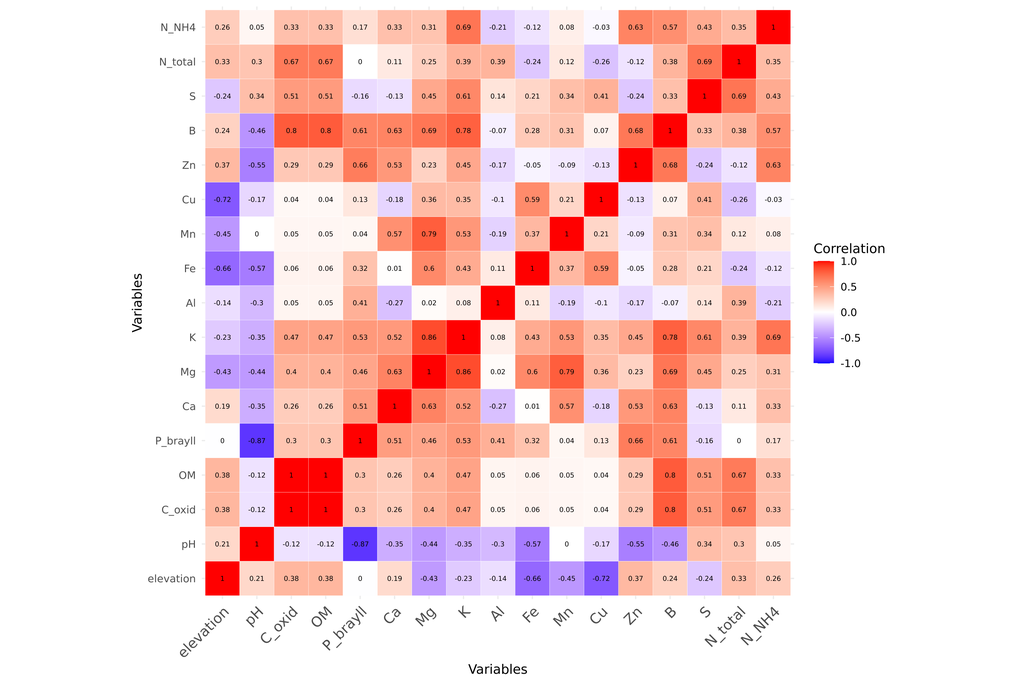

**Figure S7**: Correlation heatmap of bulk soil physicochemical variables measured at each sampling location (n = 12). Colors indicate Pearson correlation among soil variables and elevation.

## Section 10: Model structure and model selection

Every additive versus interaction decision in this appendix was made with a likelihood-ratio test or a model-comparison F-test and cross-checked against AIC, AICc, BIC and Akaike weights. The rule applied throughout is that where the interaction is not supported, the additive model is the model and is what is reported; site-specific estimates from an unsupported interaction are not treated as results. The two frameworks agree everywhere except in two places, both of which make the reported models more conservative: for NRI, AICc prefers the site-only model over both the additive and interaction models (the additive model is retained, and habitat is not significant in it); and for Helotiales habitat × site, the likelihood-ratio test gives $p=0.042$ but AICc does not support the interaction (ΔAICc +1.5), so the additive model is retained. On this basis the interaction is retained only for abundance-weighted PD at q = 1 and q = 2.

Table S21. Model structure for per-plant Hill diversity (rarefied to 28,122 reads) under three error families: AICc of the site-only, additive (habitat + site) and interaction (habitat × site) models; dAICc habitat = AICc(habitat + site) − AICc(site only); dAICc int. = AICc(habitat × site) − AICc(habitat + site); Best = lowest-AICc model. Log-normal AICc includes the Jacobian of the log transform so that it is comparable with the other families. The reported models are gamma with a log link (gamma_log).

| Metric | Family | AICc site | AICc add. | AICc int. | dAICc habitat | dAICc int. | Best |
| --- | --- | --- | --- | --- | --- | --- | --- |
| TD q=0 | gaussian | 635.62 | 618.37 | 625.86 | -17.26 | 7.49 | habitat + site |
| TD q=0 | lognormal | 639.01 | 629.08 | 633.78 | -9.93 | 4.70 | habitat + site |
| TD q=0 | gamma_log | 634.29 | 621.30 | 626.96 | -12.98 | 5.66 | habitat + site |
| TD q=1 | gaussian | 459.21 | 456.92 | 464.89 | -2.29 | 7.97 | habitat + site |
| TD q=1 | lognormal | 439.93 | 440.86 | 445.33 | 0.93 | 4.46 | site only |
| TD q=1 | gamma_log | 440.56 | 438.55 | 443.61 | -2.01 | 5.06 | habitat + site |
| TD q=2 | gaussian | 385.69 | 386.54 | 393.90 | 0.85 | 7.36 | site only |
| TD q=2 | lognormal | 361.65 | 364.45 | 369.49 | 2.80 | 5.04 | site only |
| TD q=2 | gamma_log | 364.01 | 364.54 | 369.38 | 0.54 | 4.84 | site only |
| PD q=0 | gaussian | 378.34 | 361.10 | 369.43 | -17.24 | 8.33 | habitat + site |
| PD q=0 | lognormal | 383.82 | 373.10 | 379.50 | -10.73 | 6.41 | habitat + site |
| PD q=0 | gamma_log | 380.19 | 366.66 | 374.06 | -13.53 | 7.39 | habitat + site |
| PD q=1 | gaussian | 76.13 | 74.02 | 69.78 | -2.11 | -4.24 | habitat * site |
| PD q=1 | lognormal | 42.59 | 40.95 | 36.13 | -1.65 | -4.82 | habitat * site |
| PD q=1 | gamma_log | 48.60 | 45.13 | 39.04 | -3.47 | -6.09 | habitat * site |
| PD q=2 | gaussian | -41.42 | -46.20 | -68.78 | -4.78 | -22.57 | habitat * site |
| PD q=2 | lognormal | -59.06 | -63.08 | -78.74 | -4.02 | -15.66 | habitat * site |
| PD q=2 | gamma_log | -56.89 | -61.20 | -77.99 | -4.32 | -16.79 | habitat * site |

Table S22. Model selection for centroid-based turnover, abundance-weighted NRI and NTI (linear models, n = 60 plants) and Helotiales and Sebacinales relative abundance (beta regressions): site-only, additive and interaction models compared by AICc (dAICc relative to the best model; Weight = Akaike weight) and BIC. Per-plant diversity is given in Table S21.

| Response | Model | k | logLik | AICc | dAICc | Weight | BIC |
| --- | --- | --- | --- | --- | --- | --- | --- |
| dist_centroid | site only | 5 | -165.188 | 341.487 | 7.194 | 0.025 | 350.847 |
| dist_centroid | habitat + site | 7 | -159.069 | 334.292 | 0.000 | 0.916 | 346.799 |
| dist_centroid | habitat * site | 11 | -156.146 | 339.792 | 5.499 | 0.059 | 357.330 |
| NRI_aw | site only | 5 | -107.896 | 226.903 | 0.000 | 0.748 | 236.264 |
| NRI_aw | habitat + site | 7 | -107.074 | 230.301 | 3.398 | 0.137 | 242.808 |
| NRI_aw | habitat * site | 11 | -101.573 | 230.647 | 3.743 | 0.115 | 248.184 |
| NTI_aw | site only | 5 | -106.932 | 224.975 | 0.000 | 0.790 | 234.336 |
| NTI_aw | habitat + site | 7 | -105.990 | 228.134 | 3.158 | 0.163 | 240.640 |
| NTI_aw | habitat * site | 11 | -101.560 | 230.621 | 5.645 | 0.047 | 248.159 |
| helotiales (elevation) | site only | 5 | 17.210 | -23.308 | 2.994 | 0.114 | -13.948 |
| helotiales (elevation) | elevation + site | 6 | 19.943 | -26.302 | 0.000 | 0.510 | -15.321 |
| helotiales (elevation) | elevation * site | 9 | 23.644 | -25.689 | 0.613 | 0.375 | -10.439 |
| helotiales (habitat) | site only | 5 | 17.210 | -23.308 | 2.951 | 0.134 | -13.948 |
| helotiales (habitat) | habitat + site | 7 | 21.207 | -26.260 | 0.000 | 0.585 | -13.753 |
| helotiales (habitat) | habitat * site | 11 | 26.150 | -24.800 | 1.460 | 0.282 | -7.262 |
| sebacinales (elevation) | site only | 5 | 90.607 | -170.103 | 1.520 | 0.298 | -160.742 |
| sebacinales (elevation) | elevation + site | 6 | 92.604 | -171.622 | 0.000 | 0.638 | -160.641 |
| sebacinales (elevation) | elevation * site | 9 | 94.305 | -167.010 | 4.613 | 0.064 | -151.761 |
| sebacinales (habitat) | site only | 5 | 90.607 | -170.103 | 0.000 | 0.764 | -160.742 |
| sebacinales (habitat) | habitat + site | 7 | 91.880 | -167.606 | 2.497 | 0.219 | -155.100 |
| sebacinales (habitat) | habitat * site | 11 | 94.979 | -162.458 | 7.644 | 0.017 | -144.921 |

Table S23. Support for habitat in the per-genus negative binomial GLMMs (56 genera; Section 6.3): dAICc habitat = AICc(habitat + site) − AICc(site only), with Supported = TRUE where dAICc habitat < −2; Omnibus p/q = likelihood-ratio test of habitat and its Benjamini–Hochberg q-value across genera; S vs F q and P vs F q = BH q-values of the subpáramo and páramo contrasts against forest (NA where the genus is absent from forest or the contrast is not estimable).

| Genus | Order | dAICc habitat | Supported | Omnibus p | Omnibus q | S vs F q | P vs F q |
| --- | --- | --- | --- | --- | --- | --- | --- |
| Acephala | Helotiales | -9.7817 | TRUE | 0.0005 | 0.0287 | NA | NA |
| Conlarium | Atractosporales | -8.4945 | TRUE | 0.0010 | 0.0287 | NA | NA |
| Capnobotryella | Mycosphaerellales | -6.3836 | TRUE | 0.0030 | 0.0424 | 0.0094 | 0.0141 |
| Oidiodendron | Helotiales | -6.3234 | TRUE | 0.0031 | 0.0424 | 0.1737 | 0.0141 |
| Trichoderma | Hypocreales | -5.6949 | TRUE | 0.0042 | 0.0465 | 0.0827 | 0.3306 |
| Pezicula | Helotiales | -4.5478 | TRUE | 0.0075 | 0.0687 | 0.7619 | 0.1463 |
| Cephalotheca | Cephalothecales | -3.1725 | TRUE | 0.0149 | 0.1162 | 0.0094 | 0.5491 |
| Cyphellophora | Chaetothyriales | -2.9220 | TRUE | 0.0169 | 0.1162 | 0.7619 | NA |
| Cladosporium | Cladosporiales | -2.6665 | TRUE | 0.0192 | 0.1174 | 0.1053 | 0.0990 |
| Sistotrema | Cantharellales | -1.0662 | FALSE | 0.0427 | 0.2179 | 0.0592 | 0.4657 |
| Tetracladium | Helotiales | -0.9568 | FALSE | 0.0452 | 0.2179 | 0.9302 | NA |
| Pochonia | Hypocreales | -0.8538 | FALSE | 0.0475 | 0.2179 | NA | NA |
| Lachnum | Helotiales | -0.3974 | FALSE | 0.0597 | 0.2527 | 0.0592 | 0.9875 |
| Gyoerffyella | Helotiales | -0.2148 | FALSE | 0.0654 | 0.2571 | 0.2777 | 0.0131 |
| Leptobacillium | Hypocreales | 0.6149 | FALSE | 0.0991 | 0.3420 | 0.7619 | 0.0872 |
| Basidiodendron | Auriculariales | 0.6230 | FALSE | 0.0995 | 0.3420 | 0.5980 | 0.0990 |
| Serendipita | Sebacinales | 0.8289 | FALSE | 0.1103 | 0.3554 | 0.8548 | 0.1838 |
| Oliveonia | Cantharellales | 0.9356 | FALSE | 0.1163 | 0.3554 | 0.1053 | 0.1993 |
| Cryptodiscus | Ostropales | 1.5428 | FALSE | 0.1576 | 0.4308 | NA | NA |
| Clavaria | Agaricales | 1.5519 | FALSE | 0.1583 | 0.4308 | 0.7619 | 0.0872 |
| Umbelopsis | Umbelopsidales | 1.7054 | FALSE | 0.1709 | 0.4308 | 0.9857 | 0.3388 |
| Sclerococcum | Sclerococcales | 1.7219 | FALSE | 0.1723 | 0.4308 | 0.5980 | 0.6476 |
| Coniochaeta | Coniochaetales | 2.1836 | FALSE | 0.2171 | 0.4983 | 0.7619 | 0.2329 |
| Capronia | Chaetothyriales | 2.1868 | FALSE | 0.2174 | 0.4983 | 0.2908 | 0.4109 |
| Knufia | Chaetothyriales | 2.4357 | FALSE | 0.2462 | 0.5321 | NA | NA |
| Podila | Mortierellales | 2.6277 | FALSE | 0.2710 | 0.5321 | 0.7619 | 0.9875 |
| Ilyonectria | Hypocreales | 2.6290 | FALSE | 0.2712 | 0.5321 | 0.4430 | 0.5491 |
| Piskurozyma | Filobasidiales | 2.6455 | FALSE | 0.2735 | 0.5321 | 0.8548 | 0.5343 |
| Archaeorhizomyces | Archaeorhizomycetales | 2.7579 | FALSE | 0.2893 | 0.5321 | 0.8548 | 0.3949 |
| Apiotrichum | Trichosporonales | 2.8418 | FALSE | 0.3017 | 0.5321 | NA | NA |
| Pezoloma | Helotiales | 2.9091 | FALSE | 0.3120 | 0.5321 | NA | NA |
| Calyptrozyma | Eurotiomycetidae (inc. sed.) | 2.9851 | FALSE | 0.3241 | 0.5321 | 0.7596 | 0.3251 |
| Luellia | Trechisporales | 3.0681 | FALSE | 0.3378 | 0.5321 | 0.7619 | 0.4029 |
| Linnemannia | Mortierellales | 3.1588 | FALSE | 0.3535 | 0.5321 | 0.5502 | 0.7030 |
| Teratosphaeria | Mycosphaerellales | 3.1938 | FALSE | 0.3597 | 0.5321 | NA | NA |
| Exophiala | Chaetothyriales | 3.2068 | FALSE | 0.3621 | 0.5321 | 0.7619 | 0.3251 |
| Dissophora | Mortierellales | 3.2122 | FALSE | 0.3631 | 0.5321 | 0.7619 | 0.5491 |
| Microdochium | Xylariales | 3.2371 | FALSE | 0.3676 | 0.5321 | 0.8612 | 0.3949 |
| Tolypocladium | Hypocreales | 3.3844 | FALSE | 0.3957 | 0.5467 | 0.8612 | 0.5343 |
| Paraphaeosphaeria | Pleosporales | 3.4067 | FALSE | 0.4001 | 0.5467 | 0.5980 | 0.7074 |
| Pestalotiopsis | Amphisphaeriales | 3.4432 | FALSE | 0.4075 | 0.5467 | NA | NA |
| Trechispora | Trechisporales | 3.5604 | FALSE | 0.4321 | 0.5658 | 0.9857 | 0.4029 |
| Haptocillium | Hypocreales | 3.7698 | FALSE | 0.4798 | 0.6137 | 0.8548 | 0.4168 |
| Mycena | Agaricales | 3.8602 | FALSE | 0.5020 | 0.6275 | 0.8612 | 0.3388 |
| Cladophialophora | Chaetothyriales | 4.0192 | FALSE | 0.5435 | 0.6643 | 0.7619 | 0.9145 |
| Entoloma | Agaricales | 4.1472 | FALSE | 0.5794 | 0.6928 | 0.8612 | 0.5343 |
| Hyaloscypha | Helotiales | 4.2475 | FALSE | 0.6092 | 0.7129 | 0.8612 | 0.5343 |
| Athelopsis | Atheliales | 4.3022 | FALSE | 0.6261 | 0.7174 | 0.7619 | 0.5343 |
| Mortierella | Mortierellales | 4.4472 | FALSE | 0.6732 | 0.7427 | 0.9284 | 0.5491 |
| Leohumicola | Helotiales | 4.4531 | FALSE | 0.6752 | 0.7427 | 0.7619 | 0.5491 |
| Arachnopeziza | Helotiales | 4.6685 | FALSE | 0.7520 | 0.8019 | 0.7619 | 0.6476 |
| Sympodiella | Venturiales | 4.6849 | FALSE | 0.7582 | 0.8019 | 0.9302 | 0.6476 |
| Penicillium | Eurotiales | 4.8437 | FALSE | 0.8208 | 0.8412 | 0.8612 | 0.9827 |
| Chloridium | Chaetosphaeriales | 4.8560 | FALSE | 0.8259 | 0.8412 | 0.8612 | 0.6476 |
| Metapochonia | Hypocreales | 5.2100 | FALSE | 0.9858 | 0.9858 | 0.9302 | 0.9875 |
| Clavulinopsis | Agaricales | NA | NA | NA | NA | NA | NA |

**Model selection (Scripts/model_selection_aicc.R, Scripts/family_sensitivity.R)**

```r
# Run from the repository root (after the per-plant, genus and NRI/NTI scripts):
#   Rscript Scripts/model_selection_aicc.R   # AIC, AICc, BIC and Akaike weights for every additive vs
#                                            # interaction decision; Jacobian-corrected family screen
#   Rscript Scripts/family_sensitivity.R     # per-plant habitat results and structure under gaussian,
#                                            # lognormal and gamma
#
# Key outputs saved:
#   - tables/family_sensitivity_structure.csv  (Table S21)
#   - tables/model_selection_aicc.csv          (Table S22; its per-plant rows are log-normal fits,
#                                               superseded by Table S21)
#   - tables/model_selection_aicc_genus.csv    (Table S23)
#   - tables/model_selection_family_screen.csv, family_sensitivity_habitat.csv,
#     family_sensitivity_contrasts.csv
```